# Estimación multi-contaminante de la calidad del aire en Chile

#### 3.3.9 Dispersión diaria y horaria (nacional)

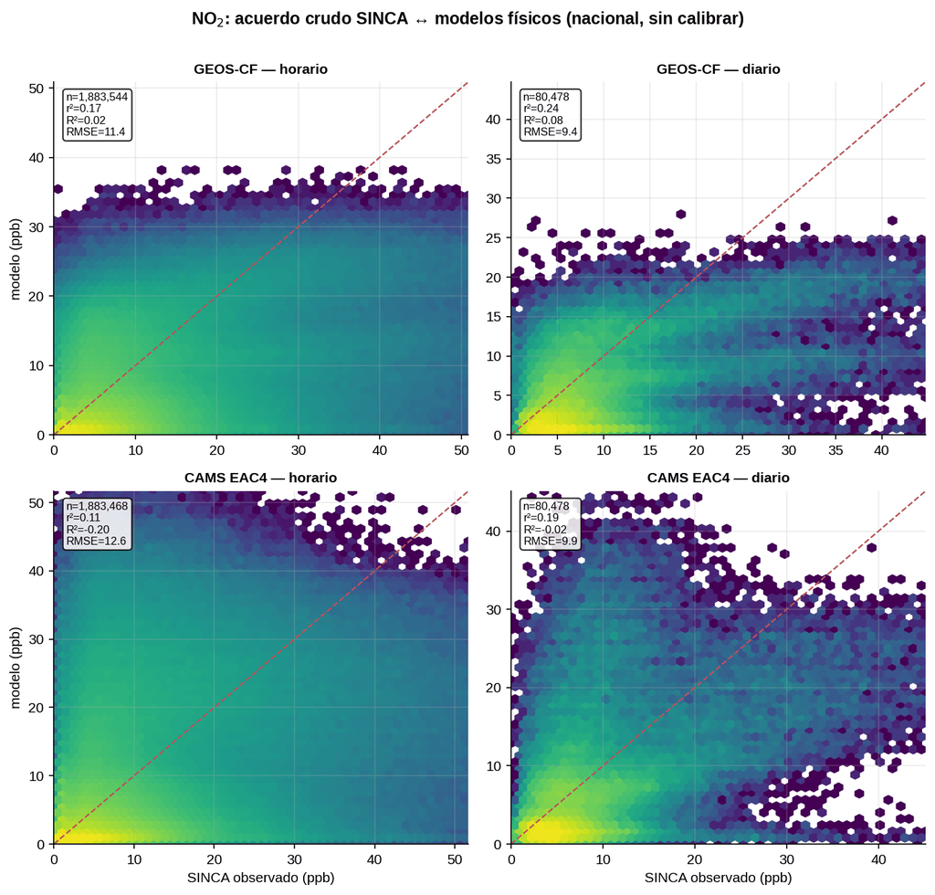

| modelo | n horario | R² horario | RMSE horario | sesgo horario | n diario | R² diario | RMSE diario | sesgo diario |
| --- | --- | --- | --- | --- | --- | --- | --- | --- |
| GEOS-CF | 1883544 | 0.02 | 11.409 | -3.948 | 80478 | 0.076 | 9.422 | -3.939 |
| CAMS EAC4 | 1883468 | -0.196 | 12.606 | -1.884 | 80478 | -0.016 | 9.881 | -1.909 |

#### 3.3.10 Por macrozona

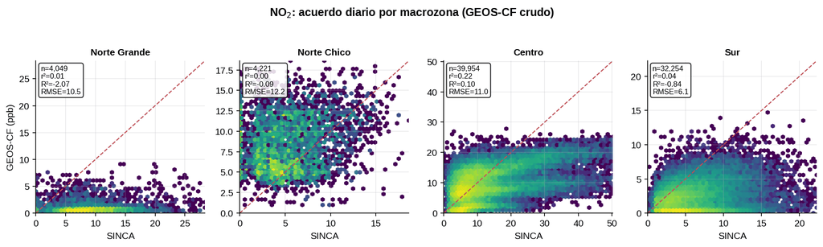

| zona | modelo | n horario | R² horario | RMSE horario | sesgo horario | n diario | R² diario | RMSE diario | sesgo diario |
| --- | --- | --- | --- | --- | --- | --- | --- | --- | --- |
| Norte Grande | GEOS-CF | 94365 | -0.672 | 13.636 | -8.701 | 4049 | -2.066 | 10.52 | -8.625 |
| Norte Grande | CAMS EAC4 | 94361 | -0.602 | 13.347 | -8.234 | 4049 | -1.836 | 10.119 | -8.164 |
| Norte Chico | GEOS-CF | 97115 | -0.189 | 13.683 | 2.483 | 4221 | -0.085 | 12.19 | 2.43 |
| Norte Chico | CAMS EAC4 | 97111 | -0.098 | 13.151 | -3.815 | 4221 | -0.104 | 12.298 | -3.822 |
| Centro | GEOS-CF | 943948 | 0.03 | 13.264 | -4.044 | 39954 | 0.102 | 11.031 | -4.027 |
| Centro | CAMS EAC4 | 943912 | -0.27 | 15.177 | 0.209 | 39954 | -0.031 | 11.82 | 0.204 |
| Sur | GEOS-CF | 748116 | -0.4 | 7.614 | -4.063 | 32254 | -0.84 | 6.118 | -4.076 |
| Sur | CAMS EAC4 | 748084 | -0.557 | 8.03 | -3.474 | 32254 | -0.863 | 6.156 | -3.491 |

#### 3.3.11 Por región

| zona | modelo | n horario | R² horario | RMSE horario | sesgo horario | n diario | R² diario | RMSE diario | sesgo diario |
| --- | --- | --- | --- | --- | --- | --- | --- | --- | --- |
| Antofagasta | GEOS-CF | 94365 | -0.672 | 13.636 | -8.701 | 4049 | -2.066 | 10.52 | -8.625 |
| Antofagasta | CAMS EAC4 | 94361 | -0.602 | 13.347 | -8.234 | 4049 | -1.836 | 10.119 | -8.164 |
| Atacama | GEOS-CF | 97115 | -0.189 | 13.683 | 2.483 | 4221 | -0.085 | 12.19 | 2.43 |
| Atacama | CAMS EAC4 | 97111 | -0.098 | 13.151 | -3.815 | 4221 | -0.104 | 12.298 | -3.822 |
| Valparaíso | GEOS-CF | 508692 | -0.818 | 7.68 | 0.021 | 21567 | -0.957 | 5.761 | 0.036 |
| Valparaíso | CAMS EAC4 | 508672 | -3.963 | 12.689 | 6.351 | 21567 | -5.222 | 10.271 | 6.342 |
| Metropolitana | GEOS-CF | 383769 | -0.191 | 18.484 | -9.059 | 16199 | -0.237 | 15.711 | -9.055 |
| Metropolitana | CAMS EAC4 | 383755 | -0.196 | 18.517 | -7.304 | 16199 | 0.003 | 14.104 | -7.331 |
| Maule | GEOS-CF | 51487 | -0.734 | 9.81 | -6.822 | 2188 | -1.792 | 8.217 | -6.844 |
| Maule | CAMS EAC4 | 51485 | -0.383 | 8.762 | -4.477 | 2188 | -0.597 | 6.214 | -4.511 |
| Biobío–Ñuble | GEOS-CF | 696647 | -0.402 | 7.58 | -4.013 | 30061 | -0.85 | 6.075 | -4.029 |
| Biobío–Ñuble | CAMS EAC4 | 696615 | -0.584 | 8.056 | -3.451 | 30061 | -0.916 | 6.183 | -3.47 |
| Araucanía | GEOS-CF | 51160 | -0.381 | 8.062 | -4.726 | 2179 | -0.777 | 6.683 | -4.705 |
| Araucanía | CAMS EAC4 | 51160 | -0.255 | 7.685 | -3.766 | 2179 | -0.32 | 5.759 | -3.76 |
| Los Ríos | GEOS-CF | 309 | -34.052 | 7.465 | -7.231 | 14 | -43.888 | 7.222 | -7.017 |
| Los Ríos | CAMS EAC4 | 309 | -30.031 | 7.024 | -6.58 | 14 | -38.009 | 6.733 | -6.39 |

#### 3.3.12 Ambas series superpuestas

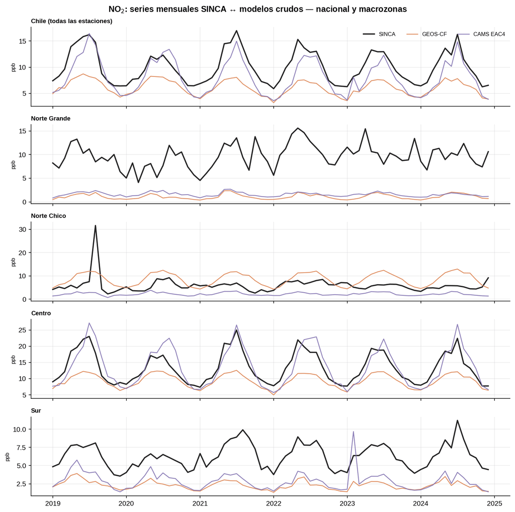

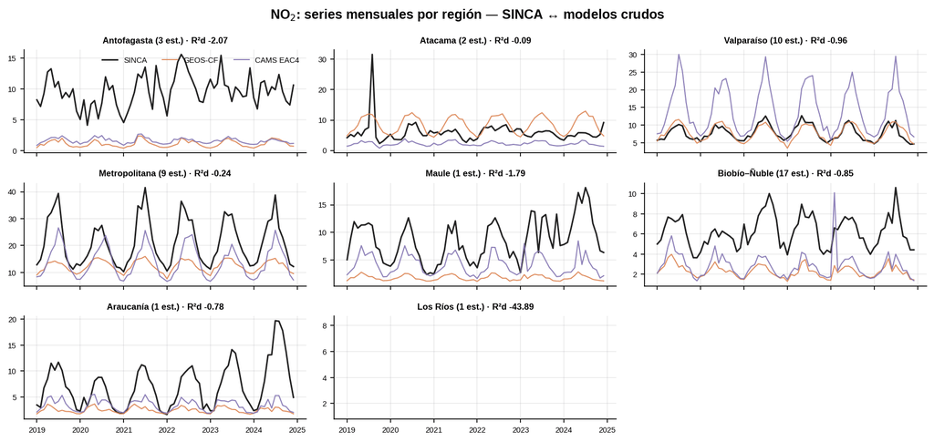

**O₃**

#### 3.3.13 Dispersión diaria y horaria (nacional)

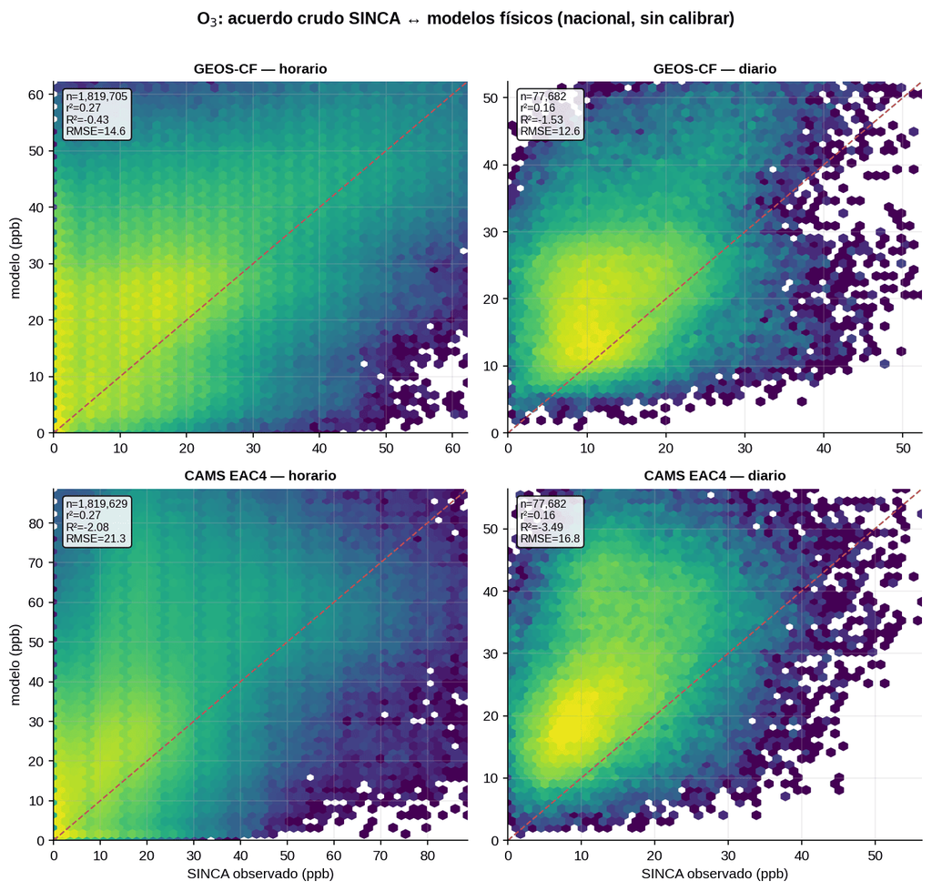

| modelo | n horario | R² horario | RMSE horario | sesgo horario | n diario | R² diario | RMSE diario | sesgo diario |
| --- | --- | --- | --- | --- | --- | --- | --- | --- |
| GEOS-CF | 1819705 | -0.431 | 14.551 | 7.882 | 77682 | -1.532 | 12.622 | 7.904 |
| CAMS EAC4 | 1819629 | -2.075 | 21.332 | 12.59 | 77682 | -3.485 | 16.798 | 12.635 |

#### 3.3.14 Por macrozona

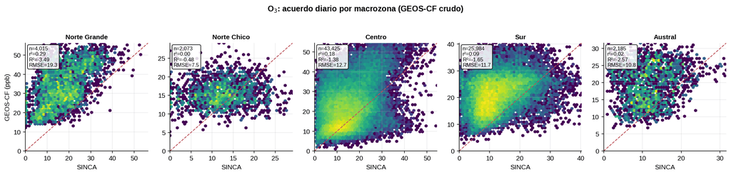

| zona | modelo | n horario | R² horario | RMSE horario | sesgo horario | n diario | R² diario | RMSE diario | sesgo diario |
| --- | --- | --- | --- | --- | --- | --- | --- | --- | --- |
| Norte Grande | GEOS-CF | 93661 | -1.948 | 20.784 | 16.734 | 4015 | -3.489 | 19.276 | 16.75 |
| Norte Grande | CAMS EAC4 | 93657 | -0.449 | 14.572 | 7.952 | 4015 | -0.458 | 10.985 | 8.068 |
| Norte Chico | GEOS-CF | 48159 | -0.614 | 10.981 | 2.716 | 2073 | -0.477 | 7.524 | 2.916 |
| Norte Chico | CAMS EAC4 | 48157 | -0.662 | 11.141 | 4.013 | 2073 | -1.082 | 8.932 | 4.164 |
| Centro | GEOS-CF | 1022324 | -0.196 | 14.89 | 6.983 | 43425 | -1.381 | 12.682 | 6.983 |
| Centro | CAMS EAC4 | 1022284 | -2.571 | 25.734 | 16.01 | 43425 | -4.912 | 19.982 | 16.082 |
| Sur | GEOS-CF | 603910 | -0.862 | 13.229 | 8.452 | 25984 | -1.654 | 11.651 | 8.486 |
| Sur | CAMS EAC4 | 603882 | -1.071 | 13.951 | 8.439 | 25984 | -1.733 | 11.823 | 8.489 |
| Austral | GEOS-CF | 51651 | -1.875 | 11.354 | 7.764 | 2185 | -2.567 | 10.803 | 7.764 |
| Austral | CAMS EAC4 | 51649 | -2.313 | 12.188 | 9.854 | 2185 | -3.164 | 11.672 | 9.848 |

#### 3.3.15 Por región

| zona | modelo | n horario | R² horario | RMSE horario | sesgo horario | n diario | R² diario | RMSE diario | sesgo diario |
| --- | --- | --- | --- | --- | --- | --- | --- | --- | --- |
| Antofagasta | GEOS-CF | 93661 | -1.948 | 20.784 | 16.734 | 4015 | -3.489 | 19.276 | 16.75 |
| Antofagasta | CAMS EAC4 | 93657 | -0.449 | 14.572 | 7.952 | 4015 | -0.458 | 10.985 | 8.068 |
| Atacama | GEOS-CF | 48159 | -0.614 | 10.981 | 2.716 | 2073 | -0.477 | 7.524 | 2.916 |
| Atacama | CAMS EAC4 | 48157 | -0.662 | 11.141 | 4.013 | 2073 | -1.082 | 8.932 | 4.164 |
| Valparaíso | GEOS-CF | 515930 | -0.511 | 13.332 | 3.953 | 21804 | -1.084 | 11.275 | 3.949 |
| Valparaíso | CAMS EAC4 | 515910 | -6.13 | 28.962 | 17.236 | 21804 | -7.1 | 22.228 | 17.287 |
| Metropolitana | GEOS-CF | 365216 | 0.225 | 15.141 | 7.93 | 15648 | -0.898 | 12.096 | 7.905 |
| Metropolitana | CAMS EAC4 | 365202 | -0.851 | 23.407 | 16.074 | 15648 | -3.412 | 18.441 | 16.177 |
| O’Higgins | GEOS-CF | 89301 | -1.371 | 20.144 | 16.085 | 3785 | -4.19 | 18.936 | 16.136 |
| O’Higgins | CAMS EAC4 | 89297 | -1.132 | 19.101 | 11.651 | 3785 | -2.441 | 15.418 | 11.764 |
| Maule | GEOS-CF | 51877 | -2.988 | 17.01 | 14.78 | 2188 | -8.185 | 16.079 | 14.779 |
| Maule | CAMS EAC4 | 51875 | -2.075 | 14.938 | 10.86 | 2188 | -4.615 | 12.572 | 10.866 |
| Biobío–Ñuble | GEOS-CF | 603685 | -0.862 | 13.225 | 8.447 | 25923 | -1.655 | 11.621 | 8.459 |
| Biobío–Ñuble | CAMS EAC4 | 603657 | -1.07 | 13.945 | 8.433 | 25923 | -1.726 | 11.776 | 8.454 |
| Los Ríos | GEOS-CF | 225 | nan | 21.229 | 20.366 | 61 | nan | 20.698 | 19.836 |
| Los Ríos | CAMS EAC4 | 225 | nan | 25.42 | 24.073 | 61 | nan | 24.773 | 23.425 |
| Aysén | GEOS-CF | 51651 | -1.875 | 11.354 | 7.764 | 2185 | -2.567 | 10.803 | 7.764 |
| Aysén | CAMS EAC4 | 51649 | -2.313 | 12.188 | 9.854 | 2185 | -3.164 | 11.672 | 9.848 |

#### 3.3.16 Ambas series superpuestas

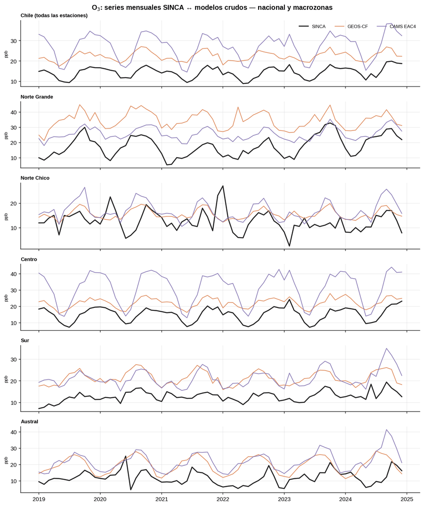

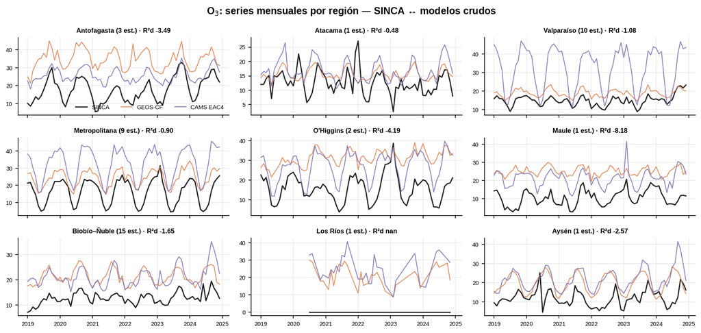

**SO₂**

#### 3.3.17 Dispersión diaria y horaria (nacional)

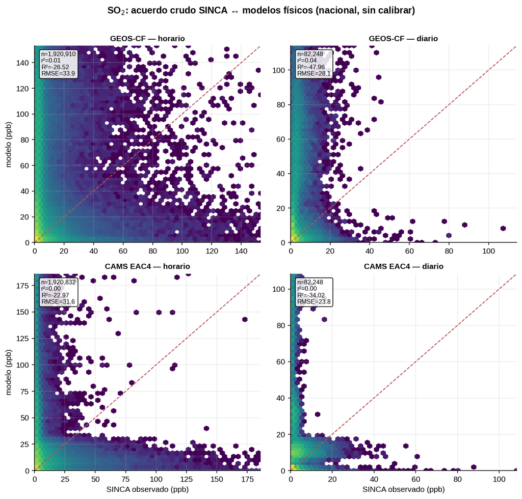

| modelo | n horario | R² horario | RMSE horario | sesgo horario | n diario | R² diario | RMSE diario | sesgo diario |
| --- | --- | --- | --- | --- | --- | --- | --- | --- |
| GEOS-CF | 1920910 | -26.524 | 33.868 | 12.595 | 82248 | -47.955 | 28.123 | 12.429 |
| CAMS EAC4 | 1920832 | -22.968 | 31.605 | 7.973 | 82248 | -34.016 | 23.784 | 7.846 |

#### 3.3.18 Por macrozona

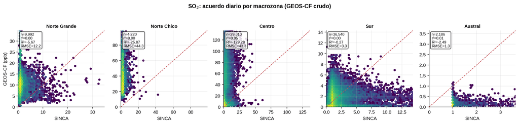

| zona | modelo | n horario | R² horario | RMSE horario | sesgo horario | n diario | R² diario | RMSE diario | sesgo diario |
| --- | --- | --- | --- | --- | --- | --- | --- | --- | --- |
| Norte Grande | GEOS-CF | 235067 | -4.523 | 15.724 | 9.5 | 9992 | -5.673 | 12.25 | 9.472 |
| Norte Grande | CAMS EAC4 | 235057 | -156.939 | 84.085 | 45.85 | 9992 | -179.203 | 63.659 | 45.644 |
| Norte Chico | GEOS-CF | 98995 | -13.72 | 53.169 | 39.139 | 4220 | -25.874 | 44.331 | 38.973 |
| Norte Chico | CAMS EAC4 | 98991 | -0.042 | 14.149 | -2.846 | 4220 | -0.111 | 9.015 | -2.848 |
| Centro | GEOS-CF | 694513 | -61.284 | 51.511 | 26.234 | 29310 | -129.277 | 43.263 | 26.267 |
| Centro | CAMS EAC4 | 694487 | -6.269 | 17.597 | 8.548 | 29310 | -11.572 | 13.439 | 8.537 |
| Sur | GEOS-CF | 840964 | -0.156 | 5.154 | -0.093 | 36540 | -0.265 | 3.284 | -0.12 |
| Sur | CAMS EAC4 | 840928 | -0.119 | 5.071 | -1.255 | 36540 | -0.268 | 3.288 | -1.267 |
| Austral | GEOS-CF | 51371 | -0.418 | 1.987 | -1.072 | 2186 | -2.492 | 1.271 | -1.072 |
| Austral | CAMS EAC4 | 51369 | -0.53 | 2.063 | -1.213 | 2186 | -3.185 | 1.392 | -1.214 |

#### 3.3.19 Por región

| zona | modelo | n horario | R² horario | RMSE horario | sesgo horario | n diario | R² diario | RMSE diario | sesgo diario |
| --- | --- | --- | --- | --- | --- | --- | --- | --- | --- |
| Antofagasta | GEOS-CF | 235067 | -4.523 | 15.724 | 9.5 | 9992 | -5.673 | 12.25 | 9.472 |
| Antofagasta | CAMS EAC4 | 235057 | -156.939 | 84.085 | 45.85 | 9992 | -179.203 | 63.659 | 45.644 |
| Atacama | GEOS-CF | 98995 | -13.72 | 53.169 | 39.139 | 4220 | -25.874 | 44.331 | 38.973 |
| Atacama | CAMS EAC4 | 98991 | -0.042 | 14.149 | -2.846 | 4220 | -0.111 | 9.015 | -2.848 |
| Valparaíso | GEOS-CF | 465122 | -64.366 | 62.57 | 36.569 | 19635 | -153.114 | 52.525 | 36.609 |
| Valparaíso | CAMS EAC4 | 465104 | -0.988 | 10.912 | 4.578 | 19635 | -1.84 | 7.131 | 4.581 |
| Metropolitana | GEOS-CF | 125844 | -116.363 | 12.662 | 8.163 | 5306 | -143.63 | 10.993 | 8.161 |
| Metropolitana | CAMS EAC4 | 125840 | -885.373 | 34.798 | 26.736 | 5306 | -921.413 | 27.763 | 26.683 |
| O’Higgins | GEOS-CF | 51602 | -74.229 | 5.589 | 3.565 | 2180 | -53.873 | 4.583 | 3.559 |
| O’Higgins | CAMS EAC4 | 51600 | -336.783 | 11.843 | 9.39 | 2180 | -242.812 | 9.661 | 9.38 |
| Maule | GEOS-CF | 51945 | -1.428 | 1.056 | -0.004 | 2189 | -0.795 | 0.815 | -0.004 |
| Maule | CAMS EAC4 | 51943 | -1.682 | 1.11 | -0.797 | 2189 | -1.934 | 1.042 | -0.796 |
| Biobío–Ñuble | GEOS-CF | 791904 | -0.154 | 5.3 | -0.046 | 34456 | -0.261 | 3.367 | -0.075 |
| Biobío–Ñuble | CAMS EAC4 | 791870 | -0.116 | 5.211 | -1.252 | 34456 | -0.26 | 3.366 | -1.266 |
| Los Ríos | GEOS-CF | 49060 | -1.77 | 1.384 | -0.864 | 2084 | -1.872 | 1.283 | -0.865 |
| Los Ríos | CAMS EAC4 | 49058 | -2.433 | 1.541 | -1.289 | 2084 | -2.919 | 1.499 | -1.291 |
| Aysén | GEOS-CF | 51371 | -0.418 | 1.987 | -1.072 | 2186 | -2.492 | 1.271 | -1.072 |
| Aysén | CAMS EAC4 | 51369 | -0.53 | 2.063 | -1.213 | 2186 | -3.185 | 1.392 | -1.214 |

#### 3.3.20 Ambas series superpuestas

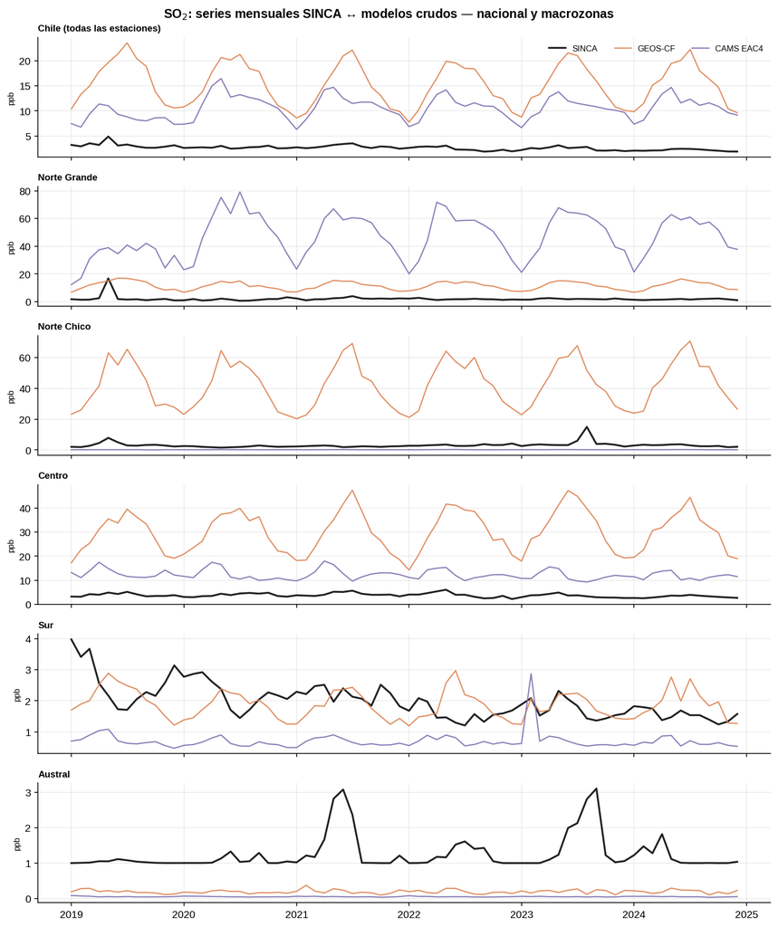

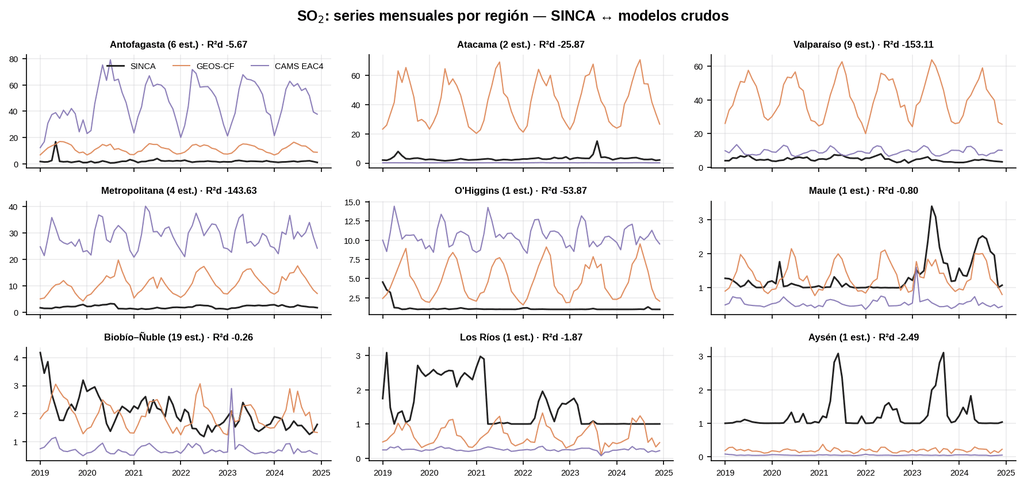

**CO**

#### 3.3.21 Dispersión diaria y horaria (nacional)

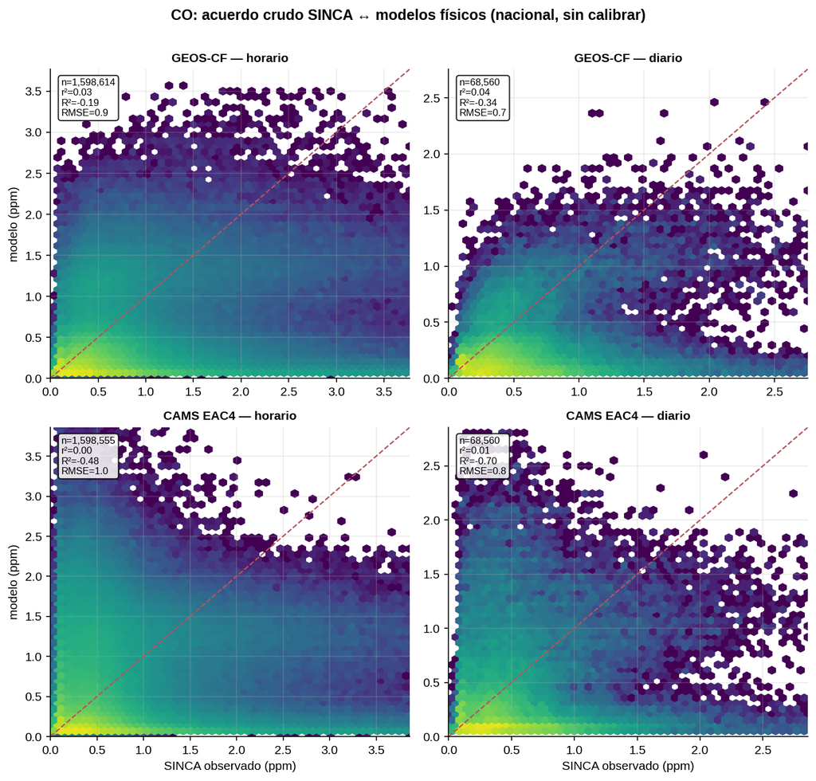

| modelo | n horario | R² horario | RMSE horario | sesgo horario | n diario | R² diario | RMSE diario | sesgo diario |
| --- | --- | --- | --- | --- | --- | --- | --- | --- |
| GEOS-CF | 1598614 | -0.191 | 0.856 | -0.323 | 68560 | -0.344 | 0.672 | -0.323 |
| CAMS EAC4 | 1598555 | -0.477 | 0.953 | -0.206 | 68560 | -0.702 | 0.756 | -0.208 |

#### 3.3.22 Por macrozona

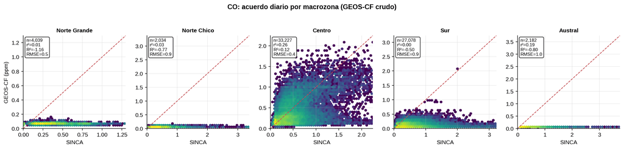

| zona | modelo | n horario | R² horario | RMSE horario | sesgo horario | n diario | R² diario | RMSE diario | sesgo diario |
| --- | --- | --- | --- | --- | --- | --- | --- | --- | --- |
| Norte Grande | GEOS-CF | 94250 | -0.382 | 0.652 | -0.342 | 4039 | -1.16 | 0.468 | -0.341 |
| Norte Grande | CAMS EAC4 | 94246 | -0.351 | 0.645 | -0.328 | 4039 | -1.059 | 0.457 | -0.328 |
| Norte Chico | GEOS-CF | 48208 | -0.397 | 1.058 | -0.566 | 2034 | -0.768 | 0.857 | -0.567 |
| Norte Chico | CAMS EAC4 | 48206 | -0.344 | 1.038 | -0.528 | 2034 | -0.667 | 0.832 | -0.529 |
| Centro | GEOS-CF | 777351 | 0.037 | 0.597 | -0.138 | 33227 | 0.115 | 0.419 | -0.137 |
| Centro | CAMS EAC4 | 777324 | -0.524 | 0.751 | 0.096 | 33227 | -0.67 | 0.575 | 0.095 |
| Sur | GEOS-CF | 627275 | -0.277 | 1.077 | -0.504 | 27078 | -0.504 | 0.876 | -0.505 |
| Sur | CAMS EAC4 | 627251 | -0.492 | 1.164 | -0.502 | 27078 | -0.738 | 0.941 | -0.502 |
| Austral | GEOS-CF | 51530 | -0.415 | 1.184 | -0.646 | 2182 | -0.801 | 0.963 | -0.646 |
| Austral | CAMS EAC4 | 51528 | -0.399 | 1.178 | -0.637 | 2182 | -0.772 | 0.956 | -0.637 |

#### 3.3.23 Por región

| zona | modelo | n horario | R² horario | RMSE horario | sesgo horario | n diario | R² diario | RMSE diario | sesgo diario |
| --- | --- | --- | --- | --- | --- | --- | --- | --- | --- |
| Antofagasta | GEOS-CF | 94250 | -0.382 | 0.652 | -0.342 | 4039 | -1.16 | 0.468 | -0.341 |
| Antofagasta | CAMS EAC4 | 94246 | -0.351 | 0.645 | -0.328 | 4039 | -1.059 | 0.457 | -0.328 |
| Atacama | GEOS-CF | 48208 | -0.397 | 1.058 | -0.566 | 2034 | -0.768 | 0.857 | -0.567 |
| Atacama | CAMS EAC4 | 48206 | -0.344 | 1.038 | -0.528 | 2034 | -0.667 | 0.832 | -0.529 |
| Valparaíso | GEOS-CF | 306331 | -0.164 | 0.392 | -0.104 | 13050 | -0.275 | 0.239 | -0.103 |
| Valparaíso | CAMS EAC4 | 306320 | -4.045 | 0.817 | 0.415 | 13050 | -9.575 | 0.688 | 0.414 |
| Metropolitana | GEOS-CF | 367726 | 0.082 | 0.642 | -0.073 | 15812 | 0.2 | 0.444 | -0.073 |
| Metropolitana | CAMS EAC4 | 367714 | 0.029 | 0.66 | -0.031 | 15812 | 0.2 | 0.443 | -0.033 |
| O’Higgins | GEOS-CF | 51650 | -0.404 | 0.541 | -0.32 | 2180 | -0.741 | 0.461 | -0.32 |
| O’Higgins | CAMS EAC4 | 51648 | -0.186 | 0.497 | -0.227 | 2180 | -0.281 | 0.395 | -0.228 |
| Maule | GEOS-CF | 51644 | -0.398 | 1.104 | -0.618 | 2185 | -1.047 | 0.83 | -0.616 |
| Maule | CAMS EAC4 | 51642 | -0.349 | 1.085 | -0.569 | 2185 | -0.868 | 0.793 | -0.567 |
| Biobío–Ñuble | GEOS-CF | 477411 | -0.315 | 1.103 | -0.537 | 20707 | -0.553 | 0.911 | -0.537 |
| Biobío–Ñuble | CAMS EAC4 | 477391 | -0.582 | 1.21 | -0.534 | 20707 | -0.836 | 0.991 | -0.535 |
| Araucanía | GEOS-CF | 100670 | -0.093 | 1.046 | -0.343 | 4286 | -0.205 | 0.775 | -0.343 |
| Araucanía | CAMS EAC4 | 100668 | -0.134 | 1.066 | -0.339 | 4286 | -0.245 | 0.788 | -0.339 |
| Los Ríos | GEOS-CF | 49194 | -0.522 | 0.86 | -0.517 | 2085 | -1.161 | 0.69 | -0.516 |
| Los Ríos | CAMS EAC4 | 49192 | -0.536 | 0.864 | -0.517 | 2085 | -1.179 | 0.693 | -0.517 |
| Aysén | GEOS-CF | 51530 | -0.415 | 1.184 | -0.646 | 2182 | -0.801 | 0.963 | -0.646 |
| Aysén | CAMS EAC4 | 51528 | -0.399 | 1.178 | -0.637 | 2182 | -0.772 | 0.956 | -0.637 |

#### 3.3.24 Ambas series superpuestas

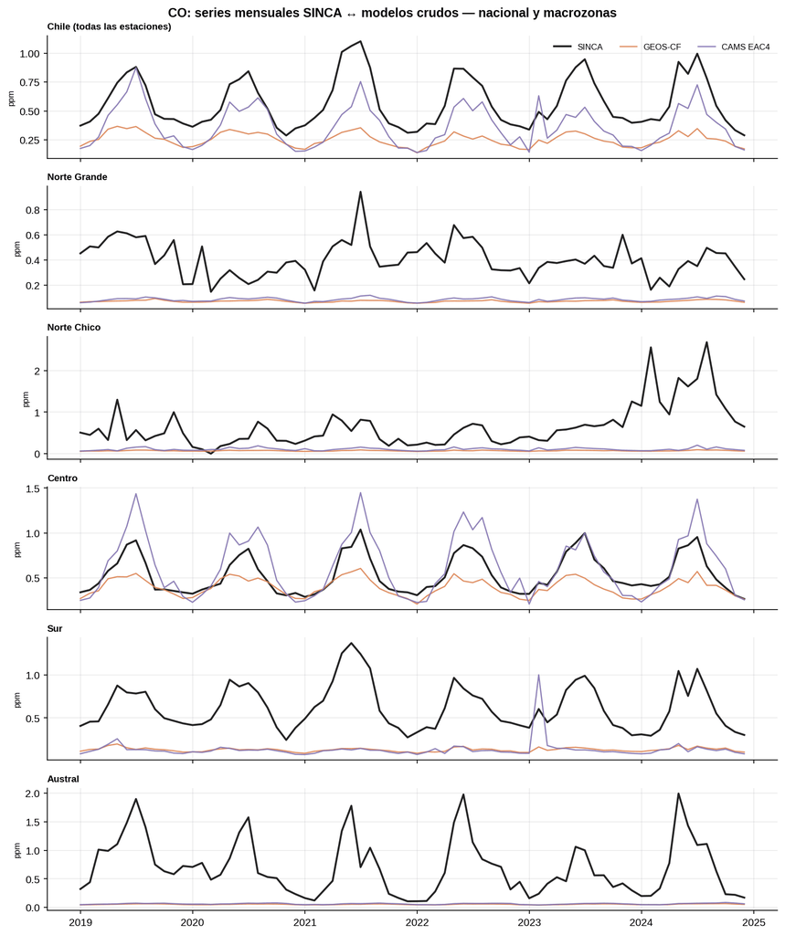

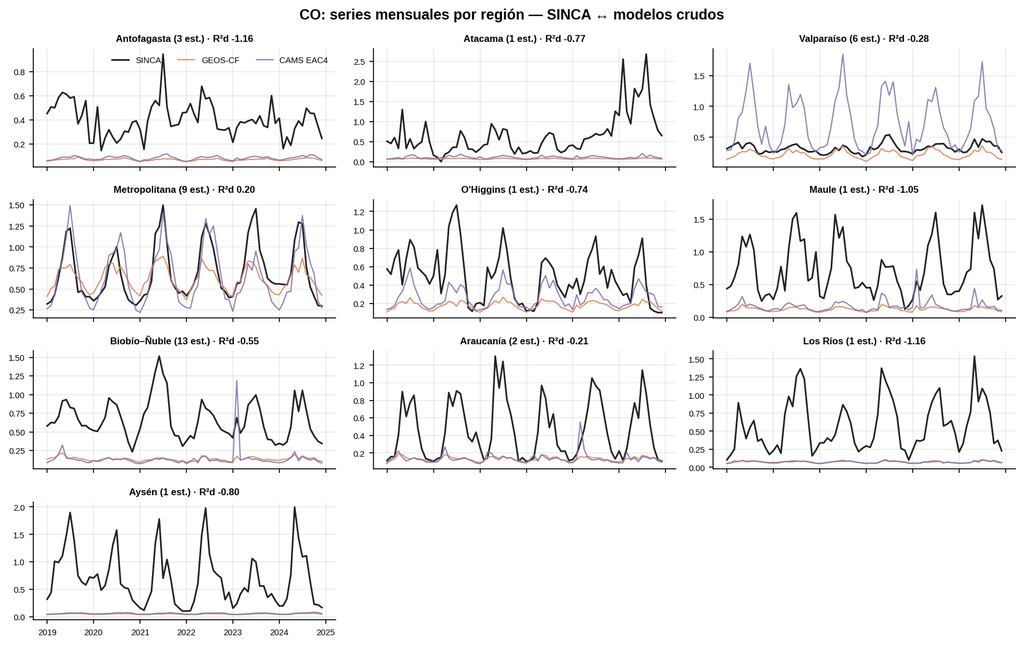

## 4 Modelos y métricas

Los tres motores de Sección 2.6 se validan bajo LOSO (Sección 2.7) para cada contaminante. Este capítulo reporta las métricas a los tres niveles del estudio: **nacional** (tabla de comparación de motores, horaria y diaria), **por macrozona** (R² agrupado del mejor motor y R² mediano por estación por motor) y **por región** (R² mediano por estación por motor), más el mapa del R² por estación y las importancias del boosting.

**Correr/cargar la validación LOSO de los seis contaminantes**

```python
resultados = {}
for pol in CONTAMINANTES:
    resultados[pol] = validar_contaminante(pol)
    m = mejor_motor(resultados[pol])
    h = resultados[pol]["motores"][m]["horario"]["r2"]
    d = resultados[pol]["motores"][m]["diario"]["r2"]
    print(f"{NOMBRE_POL_TXT[pol]:>6}: mejor motor {NOMBRE_MOTOR[m]:<18} "
          f"R² horario {h:.3f} · diario {d:.3f} "
          f"({resultados[pol]['n_filas']:,} filas, "
          f"{resultados[pol]['n_estaciones']} estaciones)")
```

```
 PM₂.₅: mejor motor LightGBM           R² horario 0.368 · diario 0.499 (4,360,160 filas, 96 estaciones)
  PM₁₀: mejor motor Regression-kriging R² horario 0.373 · diario 0.512 (3,518,524 filas, 76 estaciones)
   NO₂: mejor motor LightGBM           R² horario 0.484 · diario 0.550 (1,883,544 filas, 44 estaciones)
    O₃: mejor motor LightGBM           R² horario 0.544 · diario 0.318 (1,819,705 filas, 43 estaciones)
   SO₂: mejor motor GWR                R² horario 0.016 · diario 0.057 (1,920,910 filas, 44 estaciones)
    CO: mejor motor LightGBM           R² horario 0.223 · diario 0.225 (1,598,614 filas, 38 estaciones)
```

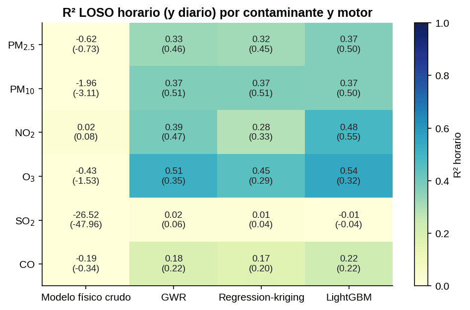

**Tabla resumen: mejor motor por contaminante**

```python
filas = []
for pol, res in resultados.items():
    m = mejor_motor(res)
    h, d = res["motores"][m]["horario"], res["motores"][m]["diario"]
    r2_est = r2_por_estacion(pol, m)["r2"].median()
    filas.append({
        "contaminante": NOMBRE_POL_TXT[pol], "unidad": UNIDADES[pol],
        "estaciones": res["n_estaciones"], "mejor motor": NOMBRE_MOTOR[m],
        "R² horario": h["r2"], "R² diario": d["r2"],
        "R² mediano por estación": round(float(r2_est), 3),
        "RMSE horario": h["rmse"], "sesgo": h["sesgo"]})
pd.DataFrame(filas).set_index("contaminante")
```

Tabla 8: Mejor motor por contaminante bajo LOSO (métricas horarias y diarias).

| contaminante | unidad | estaciones | mejor motor | R² horario | R² diario | R² mediano por estación | RMSE horario | sesgo |
| --- | --- | --- | --- | --- | --- | --- | --- | --- |
| PM₂.₅ | µg/m³ | 96 | LightGBM | 0.3680 | 0.4994 | 0.243 | 27.665 | -1.557 |
| PM₁₀ | µg/m³ | 76 | Regression-kriging | 0.3727 | 0.5117 | 0.297 | 34.692 | -0.179 |
| NO₂ | ppb | 44 | LightGBM | 0.4845 | 0.5504 | 0.118 | 8.276 | -0.825 |
| O₃ | ppb | 43 | LightGBM | 0.5437 | 0.3176 | 0.375 | 8.217 | -1.411 |
| SO₂ | ppb | 44 | GWR | 0.0159 | 0.0567 | -0.066 | 6.404 | 0.188 |
| CO | ppm | 38 | LightGBM | 0.2231 | 0.2245 | 0.076 | 0.691 | 0.001 |

La referencia de la literatura para PM₂.₅ es R² ≈ 0,81 en validación cruzada *convencional* del producto global **mensual/anual**, y 0,61–0,70 al predecir en estaciones nunca vistas; la validación de este estudio es 100 % fuera-de-estación y a resolución horaria, el escenario más exigente de los dos.

### 4.1 Efecto de la tanda nueva de predictores

Esta versión incorpora dos bloques nuevos respecto de la anterior: el **aerosol MERRA-2 por estación** (`m2_aod`, `m2_pm25`, antes solo la versión comunal) y las **covariables de fuentes puntuales de SO₂** (Sección 2.2.4). La tabla compara, contaminante a contaminante, el mejor motor LOSO y el protocolo del producto antes y después de la incorporación (mismos datos, mismos hiperparámetros, misma semilla).

**Comparación antes/después de la tanda nueva de predictores**

```python
_ruta = OUT / "comparacion_versiones.csv"
(pd.read_csv(_ruta).set_index("contaminante").round(3) if _ruta.exists()
 else Markdown("_(comparación no disponible en este entorno)_"))
```

Tabla 9: Mejor motor LOSO (R² horario y diario) y r² del producto antes y después de incorporar MERRA-2 por estación y las covariables de fuentes SO₂.

| contaminante | mejor motor (antes) | mejor motor (ahora) | R² horario antes | R² horario ahora | R² diario antes | R² diario ahora | LGBM R² horario antes | LGBM R² horario ahora | producto r² antes | producto r² ahora |
| --- | --- | --- | --- | --- | --- | --- | --- | --- | --- | --- |
| PM₂.₅ | LGBM | LGBM | 0.372 | 0.368 | 0.505 | 0.499 | 0.372 | 0.368 | 0.741 | 0.743 |
| PM₁₀ | RK | RK | 0.373 | 0.373 | 0.512 | 0.512 | 0.369 | 0.371 | 0.774 | 0.775 |
| NO₂ | LGBM | LGBM | 0.468 | 0.484 | 0.529 | 0.550 | 0.468 | 0.484 | 0.778 | 0.786 |
| O₃ | LGBM | LGBM | 0.537 | 0.544 | 0.297 | 0.318 | 0.537 | 0.544 | 0.866 | 0.865 |
| SO₂ | GWR | GWR | 0.016 | 0.016 | 0.057 | 0.057 | -0.004 | -0.012 | 0.532 | 0.528 |
| CO | LGBM | LGBM | 0.234 | 0.223 | 0.247 | 0.224 | 0.234 | 0.223 | 0.806 | 0.809 |

**Lectura.** El efecto neto es selectivo y honesto de reportar: **NO₂ y O₃ mejoran** (R² horario 0,468 → 0,484 y 0,537 → 0,544; el diario de NO₂ sube de 0,529 a 0,550) — consistente con que el AOD/PM₂.₅ de reanálisis por estación agrega información urbana y fotoquímica —, PM₁₀ queda igual, PM₂.₅ y CO ceden marginalmente (−0,004 y −0,011: las columnas nuevas que no aportan actúan como ruido en redes con pocas estaciones), y **SO₂ no mejora**. El caso SO₂ merece detalle: el boosting *sí usa* las covariables de fuente (distancia, carga y viento-desde-fuente suman ~11 % de la ganancia y quedan entre las 12 variables más importantes), pero la relación fuente → concentración aprendida en unas fuentes **no transfiere** a las otras bajo LOSO — las estaciones junto a la refinería de Hualpén empeoran justamente porque el modelo les aplica el régimen aprendido en las fundiciones. Con ~16 fuentes heterogéneas, pesos de orden de magnitud y viento a 0,5°, la extrapolación entre fuentes no es todavía aprendible; los ingredientes que faltan quedan en Sección 8 (emisiones RETC por establecimiento y año, viento local 0,1°).

**PM₂.₅**

**Lectura.** El mejor motor LOSO para PM₂.₅ horario es **LightGBM** (R² horario **0.37**, RMSE 27.7; agregado a medias diarias R² **0.50**; el modelo físico crudo queda en -0.62 horario).

#### 4.1.1 Nacional (R² agrupado LOSO)

| motor | R² horario | RMSE h | MAE h | sesgo h | R² diario | RMSE d |
| --- | --- | --- | --- | --- | --- | --- |
| Modelo físico crudo | -0.623 | 44.334 | 19.161 | 0.712 | -0.732 | 31.092 |
| GWR | 0.326 | 28.56 | 11.11 | 0.059 | 0.464 | 17.297 |
| Regression-kriging | 0.315 | 28.802 | 11.763 | 0.329 | 0.448 | 17.551 |
| LightGBM | 0.368 | 27.665 | 10.316 | -1.557 | 0.499 | 16.718 |

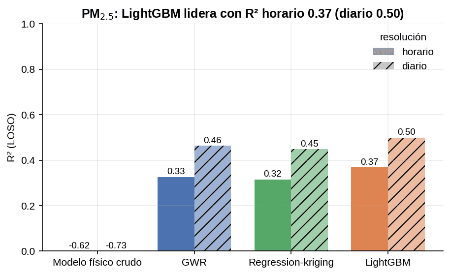

#### 4.1.2 Por macrozona

R² **agrupado** LOSO por macrozona del mejor motor (todas las horas de la macrozona juntas):

| macrozona | n horas | R² | RMSE | MAE | sesgo |
| --- | --- | --- | --- | --- | --- |
| Norte Grande | 537882.0 | -0.002 | 19.311 | 5.337 | -1.584 |
| Norte Chico | 351303.0 | -0.055 | 8.975 | 5.470 | 0.254 |
| Centro | 1534335.0 | 0.513 | 16.562 | 7.805 | -0.072 |
| Sur | 1705316.0 | 0.282 | 37.379 | 14.233 | -3.392 |
| Austral | 231324.0 | 0.596 | 36.285 | 17.029 | -0.559 |

R² LOSO **mediano por estación**, por motor (la vara dura: habilidad temporal en la estación no vista):

| zona | estaciones | R² med. físico crudo | R² med. GWR | R² med. RK | R² med. LGBM | mejor motor | RMSE mediano (mejor) |
| --- | --- | --- | --- | --- | --- | --- | --- |
| Norte Grande | 12 | -0.389 | -0.034 | -0.333 | -0.025 | LGBM | 7.87 |
| Norte Chico | 7 | -5.128 | -0.137 | -0.238 | 0.191 | LGBM | 6.25 |
| Centro | 33 | -3.53 | 0.48 | 0.489 | 0.474 | RK | 13.67 |
| Sur | 39 | -0.32 | 0.329 | 0.34 | 0.222 | RK | 33.55 |
| Austral | 5 | -0.322 | 0.255 | 0.206 | 0.283 | LGBM | 37.24 |

#### 4.1.3 Por región

| zona | estaciones | R² med. físico crudo | R² med. GWR | R² med. RK | R² med. LGBM | mejor motor | RMSE mediano (mejor) |
| --- | --- | --- | --- | --- | --- | --- | --- |
| Arica y P. | 1 | -0.156 | -0.553 | -0.937 | -0.113 | LGBM | 8.15 |
| Tarapacá | 1 | -0.175 | -0.27 | -0.583 | 0.018 | LGBM | 10.16 |
| Antofagasta | 10 | -0.545 | -0.024 | -0.301 | -0.025 | GWR | 8.22 |
| Atacama | 4 | -5.707 | -0.18 | -0.302 | 0.147 | LGBM | 6.06 |
| Coquimbo | 3 | -1.268 | 0.245 | 0.172 | 0.329 | LGBM | 7.01 |
| Valparaíso | 12 | -5.33 | 0.156 | -0.036 | 0.249 | LGBM | 10.2 |
| Metropolitana | 11 | -5.559 | 0.642 | 0.572 | 0.693 | LGBM | 12.5 |
| O’Higgins | 4 | -0.018 | 0.602 | 0.514 | 0.62 | LGBM | 17.4 |
| Maule | 6 | -0.338 | 0.502 | 0.463 | 0.462 | GWR | 22.46 |
| Biobío–Ñuble | 27 | -0.489 | 0.324 | 0.326 | 0.168 | RK | 25.19 |
| Araucanía | 4 | -0.362 | 0.387 | 0.357 | 0.436 | LGBM | 35.91 |
| Los Ríos | 3 | -0.138 | 0.237 | 0.229 | -0.031 | GWR | 38.83 |
| Los Lagos | 5 | -0.163 | 0.394 | 0.369 | 0.374 | GWR | 52.87 |
| Aysén | 4 | -0.291 | 0.411 | 0.396 | 0.502 | LGBM | 37.42 |
| Magallanes | 1 | -0.446 | -168.876 | -189.78 | -25.057 | LGBM | 20.65 |

#### 4.1.4 Mapa e importancias

[figure not shown]

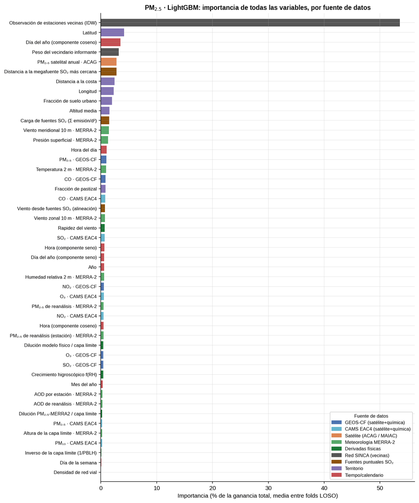

**PM₁₀**

**Lectura.** El mejor motor LOSO para PM₁₀ horario es **Regression-kriging** (R² horario **0.37**, RMSE 34.7; agregado a medias diarias R² **0.51**; el modelo físico crudo queda en -1.96 horario).

#### 4.1.5 Nacional (R² agrupado LOSO)

| motor | R² horario | RMSE h | MAE h | sesgo h | R² diario | RMSE d |
| --- | --- | --- | --- | --- | --- | --- |
| Modelo físico crudo | -1.962 | 75.379 | 36.889 | -4.235 | -3.11 | 59.594 |
| GWR | 0.371 | 34.737 | 18.455 | 0.417 | 0.507 | 20.644 |
| Regression-kriging | 0.373 | 34.692 | 18.574 | -0.179 | 0.512 | 20.541 |
| LightGBM | 0.371 | 34.743 | 17.803 | -2.092 | 0.496 | 20.87 |

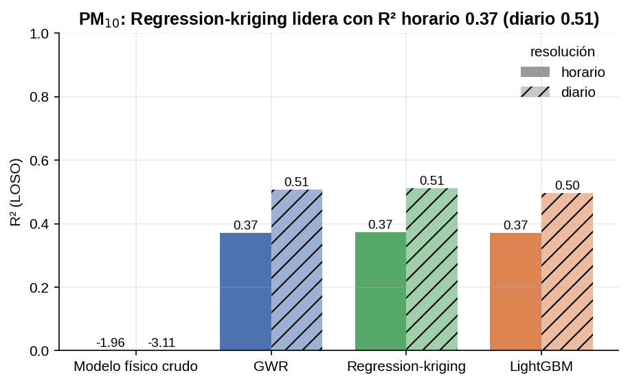

#### 4.1.6 Por macrozona

R² **agrupado** LOSO por macrozona del mejor motor (todas las horas de la macrozona juntas):

| macrozona | n horas | R² | RMSE | MAE | sesgo |
| --- | --- | --- | --- | --- | --- |
| Norte Grande | 387834.0 | -0.033 | 36.979 | 20.585 | -1.663 |
| Norte Chico | 104217.0 | -0.785 | 32.122 | 23.363 | 13.776 |
| Centro | 1462464.0 | 0.502 | 27.056 | 16.959 | 0.165 |
| Sur | 1459715.0 | 0.260 | 40.690 | 19.412 | -1.128 |
| Austral | 104294.0 | 0.818 | 32.409 | 17.227 | -0.136 |

R² LOSO **mediano por estación**, por motor (la vara dura: habilidad temporal en la estación no vista):

| zona | estaciones | R² med. físico crudo | R² med. GWR | R² med. RK | R² med. LGBM | mejor motor | RMSE mediano (mejor) |
| --- | --- | --- | --- | --- | --- | --- | --- |
| Norte Grande | 9 | -0.857 | -0.165 | -0.211 | -0.306 | GWR | 25.28 |
| Norte Chico | 2 | -0.759 | -2.881 | -2.488 | -1.63 | LGBM | 28.96 |
| Centro | 31 | -1.976 | 0.419 | 0.441 | 0.397 | RK | 25.27 |
| Sur | 32 | -2.862 | 0.292 | 0.282 | 0.216 | GWR | 33.78 |
| Austral | 2 | -0.353 | 0.824 | 0.819 | 0.741 | GWR | 31.93 |

#### 4.1.7 Por región

| zona | estaciones | R² med. físico crudo | R² med. GWR | R² med. RK | R² med. LGBM | mejor motor | RMSE mediano (mejor) |
| --- | --- | --- | --- | --- | --- | --- | --- |
| Antofagasta | 9 | -0.857 | -0.165 | -0.211 | -0.306 | GWR | 25.28 |
| Atacama | 1 | -0.826 | -0.121 | -0.103 | -0.003 | LGBM | 30.1 |
| Coquimbo | 1 | -0.692 | -5.641 | -4.874 | -3.258 | LGBM | 27.81 |
| Valparaíso | 11 | -13.404 | 0.13 | 0.076 | 0.204 | LGBM | 21.97 |
| Metropolitana | 11 | -1.534 | 0.633 | 0.564 | 0.679 | LGBM | 25.12 |
| O’Higgins | 4 | -0.463 | 0.429 | 0.423 | 0.398 | GWR | 30.93 |
| Maule | 5 | -1.768 | 0.453 | 0.444 | 0.414 | GWR | 25.15 |
| Biobío–Ñuble | 25 | -4.98 | 0.275 | 0.272 | 0.213 | GWR | 30.83 |
| Araucanía | 3 | -0.686 | 0.372 | 0.367 | 0.422 | LGBM | 35.5 |
| Los Ríos | 2 | -0.242 | -1.785 | -1.289 | -0.978 | LGBM | 45.69 |
| Los Lagos | 2 | -0.189 | 0.328 | 0.319 | 0.353 | LGBM | 58.61 |
| Aysén | 2 | -0.353 | 0.824 | 0.819 | 0.741 | GWR | 31.93 |

#### 4.1.8 Mapa e importancias

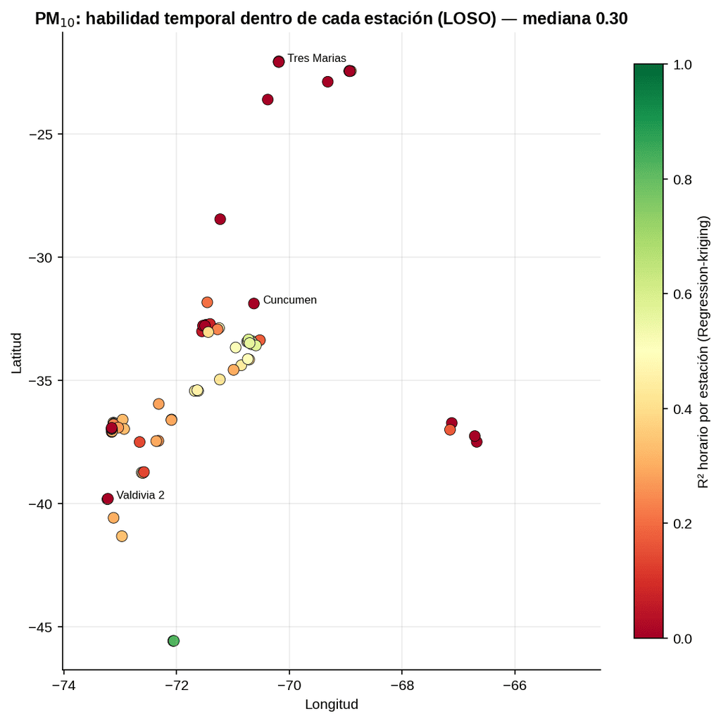

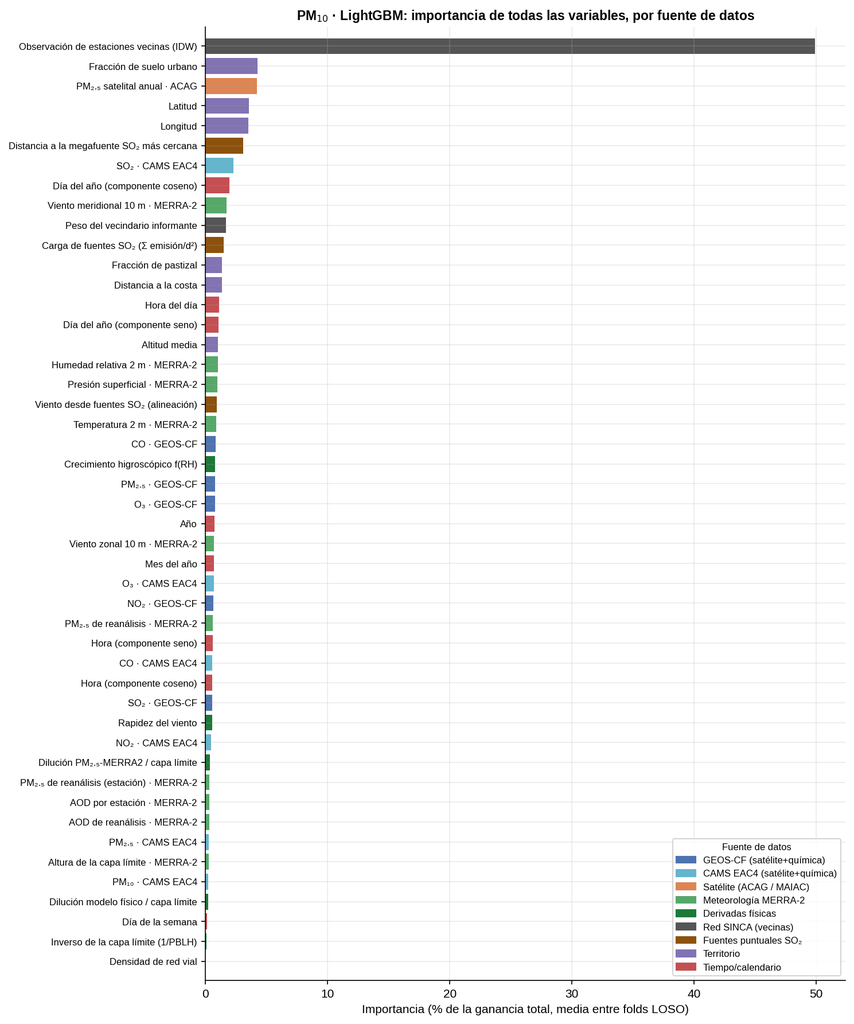

**NO₂**

**Lectura.** El mejor motor LOSO para NO₂ horario es **LightGBM** (R² horario **0.48**, RMSE 8.3; agregado a medias diarias R² **0.55**; el modelo físico crudo queda en 0.02 horario).

#### 4.1.9 Nacional (R² agrupado LOSO)

| motor | R² horario | RMSE h | MAE h | sesgo h | R² diario | RMSE d |
| --- | --- | --- | --- | --- | --- | --- |
| Modelo físico crudo | 0.02 | 11.409 | 6.846 | -3.948 | 0.076 | 9.422 |
| GWR | 0.389 | 9.01 | 5.05 | 0.023 | 0.466 | 7.167 |
| Regression-kriging | 0.282 | 9.767 | 5.689 | 0.217 | 0.326 | 8.052 |
| LightGBM | 0.484 | 8.276 | 4.484 | -0.825 | 0.55 | 6.574 |

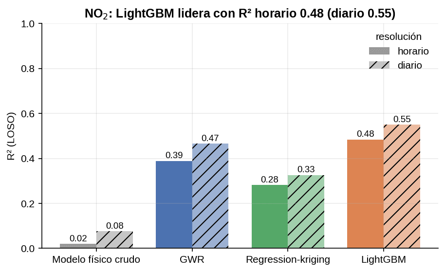

#### 4.1.10 Por macrozona

R² **agrupado** LOSO por macrozona del mejor motor (todas las horas de la macrozona juntas):

| macrozona | n horas | R² | RMSE | MAE | sesgo |
| --- | --- | --- | --- | --- | --- |
| Norte Grande | 94365.0 | -0.031 | 10.710 | 6.163 | -2.958 |
| Norte Chico | 97115.0 | -0.081 | 13.049 | 4.657 | -0.475 |
| Centro | 943948.0 | 0.561 | 8.926 | 5.028 | -0.782 |
| Sur | 748116.0 | 0.147 | 5.944 | 3.564 | -0.656 |

R² LOSO **mediano por estación**, por motor (la vara dura: habilidad temporal en la estación no vista):

| zona | estaciones | R² med. físico crudo | R² med. GWR | R² med. RK | R² med. LGBM | mejor motor | RMSE mediano (mejor) |
| --- | --- | --- | --- | --- | --- | --- | --- |
| Norte Grande | 3 | -1.026 | -0.186 | -0.256 | -0.118 | LGBM | 11.74 |
| Norte Chico | 2 | -1.495 | -6.852 | -6.314 | -0.44 | LGBM | 11.62 |
| Centro | 20 | -0.599 | -0.013 | 0.1 | 0.262 | LGBM | 6.28 |
| Sur | 19 | -0.433 | 0.005 | -0.033 | -0.023 | GWR | 5.74 |

#### 4.1.11 Por región

| zona | estaciones | R² med. físico crudo | R² med. GWR | R² med. RK | R² med. LGBM | mejor motor | RMSE mediano (mejor) |
| --- | --- | --- | --- | --- | --- | --- | --- |
| Antofagasta | 3 | -1.026 | -0.186 | -0.256 | -0.118 | LGBM | 11.74 |
| Atacama | 2 | -1.495 | -6.852 | -6.314 | -0.44 | LGBM | 11.62 |
| Valparaíso | 10 | -0.974 | -0.332 | -0.67 | 0.051 | LGBM | 5.26 |
| Metropolitana | 9 | -0.096 | 0.413 | 0.207 | 0.388 | GWR | 11.44 |
| Maule | 1 | -0.734 | 0.229 | 0.288 | 0.292 | LGBM | 6.27 |
| Biobío–Ñuble | 17 | -0.433 | 0.005 | -0.033 | -0.023 | GWR | 5.74 |
| Araucanía | 1 | -0.381 | 0.249 | 0.254 | 0.214 | RK | 5.92 |
| Los Ríos | 1 | -34.052 | -17.707 | -13.453 | -13.552 | RK | 4.79 |

#### 4.1.12 Mapa e importancias

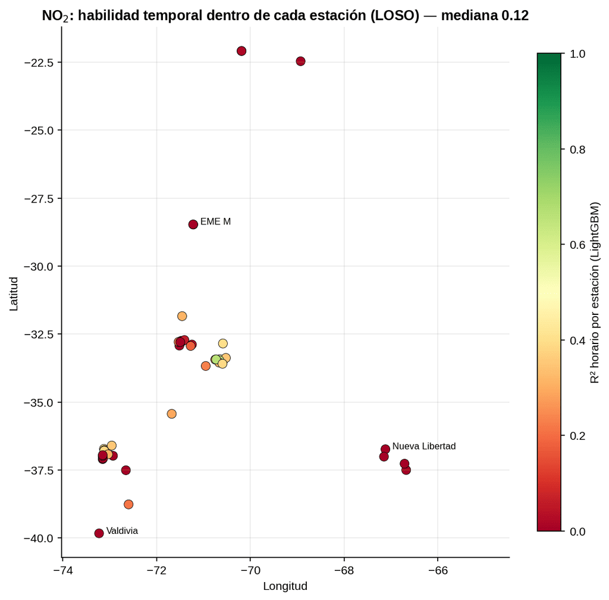

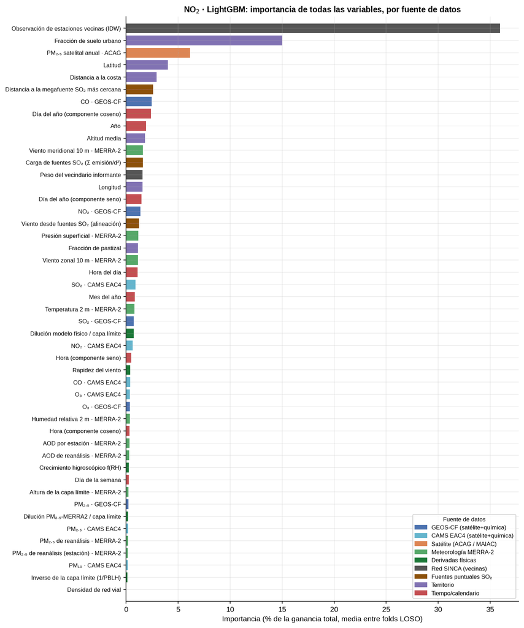

**O₃**

**Lectura.** El mejor motor LOSO para O₃ horario es **LightGBM** (R² horario **0.54**, RMSE 8.2; agregado a medias diarias R² **0.32**; el modelo físico crudo queda en -0.43 horario).

#### 4.1.13 Nacional (R² agrupado LOSO)

| motor | R² horario | RMSE h | MAE h | sesgo h | R² diario | RMSE d |
| --- | --- | --- | --- | --- | --- | --- |
| Modelo físico crudo | -0.431 | 14.551 | 11.224 | 7.882 | -1.532 | 12.622 |
| GWR | 0.512 | 8.494 | 5.907 | 0.009 | 0.349 | 6.399 |
| Regression-kriging | 0.453 | 9.001 | 6.377 | -0.603 | 0.288 | 6.691 |
| LightGBM | 0.544 | 8.217 | 5.609 | -1.411 | 0.318 | 6.552 |

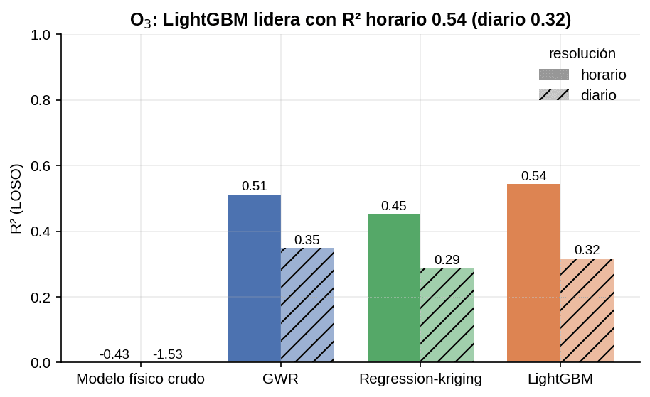

#### 4.1.14 Por macrozona

R² **agrupado** LOSO por macrozona del mejor motor (todas las horas de la macrozona juntas):

| macrozona | n horas | R² | RMSE | MAE | sesgo |
| --- | --- | --- | --- | --- | --- |
| Norte Grande | 93661.0 | 0.008 | 12.058 | 8.659 | -4.948 |
| Norte Chico | 48159.0 | -0.337 | 9.992 | 6.664 | -4.514 |
| Centro | 1022324.0 | 0.719 | 7.224 | 4.946 | -1.169 |
| Sur | 603910.0 | 0.222 | 8.549 | 5.818 | -0.314 |
| Austral | 51651.0 | -2.006 | 11.610 | 9.786 | -9.733 |

R² LOSO **mediano por estación**, por motor (la vara dura: habilidad temporal en la estación no vista):

| zona | estaciones | R² med. físico crudo | R² med. GWR | R² med. RK | R² med. LGBM | mejor motor | RMSE mediano (mejor) |
| --- | --- | --- | --- | --- | --- | --- | --- |
| Norte Grande | 3 | -3.108 | -0.162 | -0.262 | -0.015 | LGBM | 12.14 |
| Norte Chico | 1 | -0.614 | -0.257 | -0.209 | -0.337 | RK | 9.5 |
| Centro | 22 | -0.227 | 0.541 | 0.554 | 0.643 | LGBM | 6.18 |
| Sur | 16 | -0.918 | 0.255 | 0.259 | 0.158 | RK | 9.1 |
| Austral | 1 | -1.875 | -0.808 | -1.43 | -2.006 | GWR | 9.01 |

#### 4.1.15 Por región

| zona | estaciones | R² med. físico crudo | R² med. GWR | R² med. RK | R² med. LGBM | mejor motor | RMSE mediano (mejor) |
| --- | --- | --- | --- | --- | --- | --- | --- |
| Antofagasta | 3 | -3.108 | -0.162 | -0.262 | -0.015 | LGBM | 12.14 |
| Atacama | 1 | -0.614 | -0.257 | -0.209 | -0.337 | RK | 9.5 |
| Valparaíso | 10 | -0.29 | 0.234 | 0.089 | 0.406 | LGBM | 7.23 |
| Metropolitana | 9 | 0.617 | 0.876 | 0.802 | 0.896 | LGBM | 5.48 |
| O’Higgins | 2 | -1.358 | 0.702 | 0.696 | 0.725 | LGBM | 6.91 |
| Maule | 1 | -2.988 | 0.251 | 0.376 | 0.573 | LGBM | 5.57 |
| Biobío–Ñuble | 15 | -0.918 | 0.255 | 0.259 | 0.158 | RK | 9.03 |
| Los Ríos | 1 | nan | nan | nan | nan | GWR | 14.99 |
| Aysén | 1 | -1.875 | -0.808 | -1.43 | -2.006 | GWR | 9.01 |

#### 4.1.16 Mapa e importancias

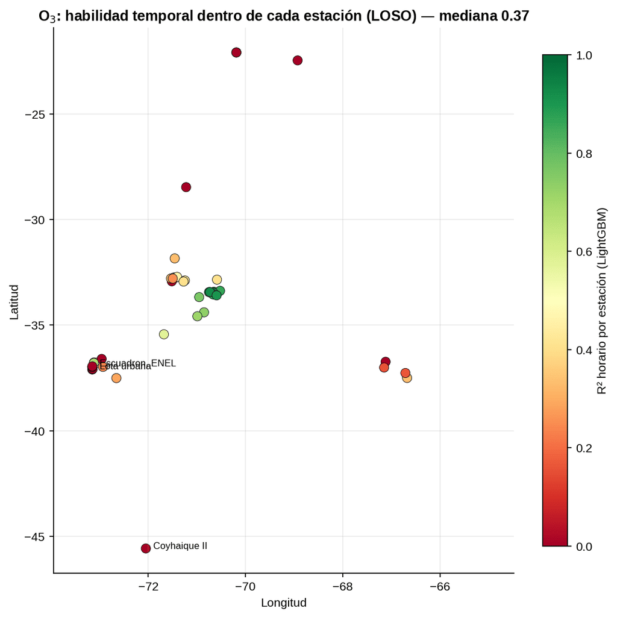

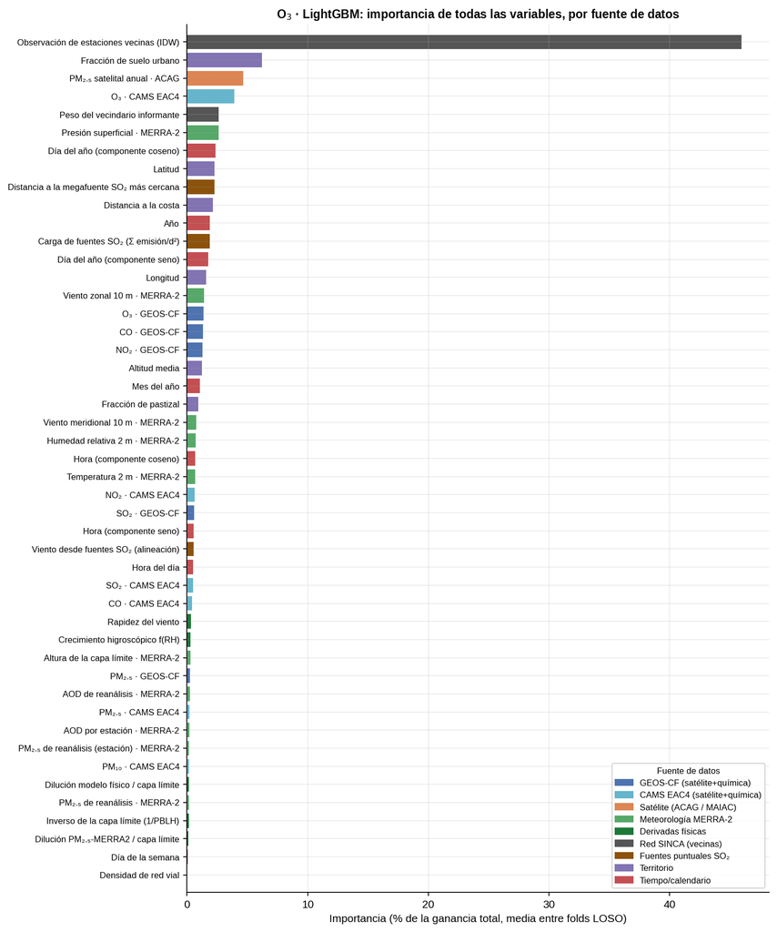

**SO₂**

**Lectura.** El mejor motor LOSO para SO₂ horario es **GWR** (R² horario **0.02**, RMSE 6.4; agregado a medias diarias R² **0.06**; el modelo físico crudo queda en -26.52 horario).

#### 4.1.17 Nacional (R² agrupado LOSO)

| motor | R² horario | RMSE h | MAE h | sesgo h | R² diario | RMSE d |
| --- | --- | --- | --- | --- | --- | --- |
| Modelo físico crudo | -26.524 | 33.868 | 14.359 | 12.595 | -47.955 | 28.123 |
| GWR | 0.016 | 6.404 | 2.203 | 0.188 | 0.057 | 3.904 |
| Regression-kriging | 0.011 | 6.419 | 2.254 | 0.262 | 0.041 | 3.935 |
| LightGBM | -0.012 | 6.496 | 1.991 | -0.397 | -0.037 | 4.092 |

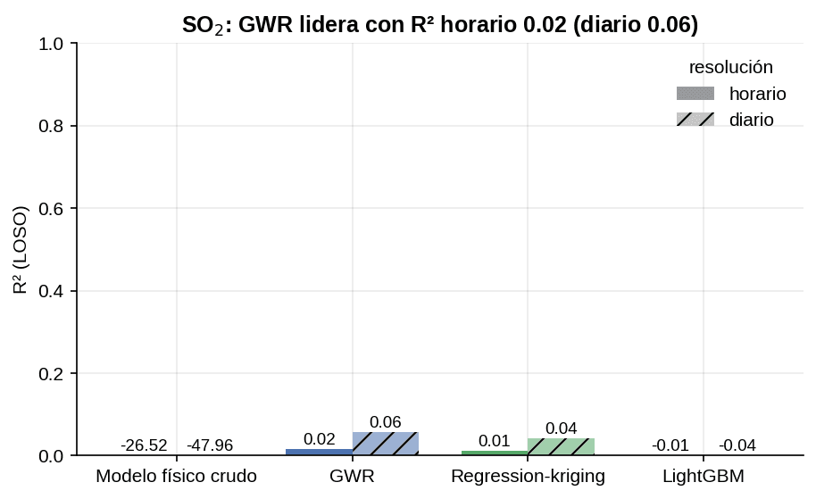

#### 4.1.18 Por macrozona

R² **agrupado** LOSO por macrozona del mejor motor (todas las horas de la macrozona juntas):

| macrozona | n horas | R² | RMSE | MAE | sesgo |
| --- | --- | --- | --- | --- | --- |
| Norte Grande | 235067.0 | 0.004 | 6.676 | 2.052 | 0.452 |
| Norte Chico | 98995.0 | -0.019 | 13.989 | 2.241 | 0.570 |
| Centro | 694513.0 | 0.017 | 6.470 | 2.979 | 0.207 |
| Sur | 840964.0 | -0.019 | 4.839 | 1.698 | 0.063 |
| Austral | 51371.0 | -0.111 | 1.759 | 0.593 | 0.049 |

R² LOSO **mediano por estación**, por motor (la vara dura: habilidad temporal en la estación no vista):

| zona | estaciones | R² med. físico crudo | R² med. GWR | R² med. RK | R² med. LGBM | mejor motor | RMSE mediano (mejor) |
| --- | --- | --- | --- | --- | --- | --- | --- |
| Norte Grande | 6 | -23.658 | -0.066 | -0.219 | 0.067 | LGBM | 2.45 |
| Norte Chico | 2 | -23.85 | -0.056 | -0.073 | -0.008 | LGBM | 13.05 |
| Centro | 15 | -23.227 | -0.4 | -0.125 | -0.274 | RK | 4.61 |
| Sur | 20 | -0.457 | -0.042 | -0.042 | -0.076 | GWR | 4.18 |
| Austral | 1 | -0.418 | -0.111 | -0.17 | -0.764 | GWR | 1.76 |

#### 4.1.19 Por región

| zona | estaciones | R² med. físico crudo | R² med. GWR | R² med. RK | R² med. LGBM | mejor motor | RMSE mediano (mejor) |
| --- | --- | --- | --- | --- | --- | --- | --- |
| Antofagasta | 6 | -23.658 | -0.066 | -0.219 | 0.067 | LGBM | 2.45 |
| Atacama | 2 | -23.85 | -0.056 | -0.073 | -0.008 | LGBM | 13.05 |
| Valparaíso | 9 | -36.886 | -0.019 | -0.073 | -0.222 | GWR | 6.7 |
| Metropolitana | 4 | -15.783 | -1.556 | -0.958 | -0.554 | LGBM | 1.18 |
| O’Higgins | 1 | -74.229 | -12.652 | -7.059 | -2.959 | LGBM | 1.28 |
| Maule | 1 | -1.428 | -2.389 | -3.844 | -0.511 | LGBM | 0.83 |
| Biobío–Ñuble | 19 | -0.28 | -0.037 | -0.036 | -0.065 | RK | 4.26 |
| Los Ríos | 1 | -1.77 | -0.353 | -0.755 | -0.354 | GWR | 0.97 |
| Aysén | 1 | -0.418 | -0.111 | -0.17 | -0.764 | GWR | 1.76 |

#### 4.1.20 Mapa e importancias

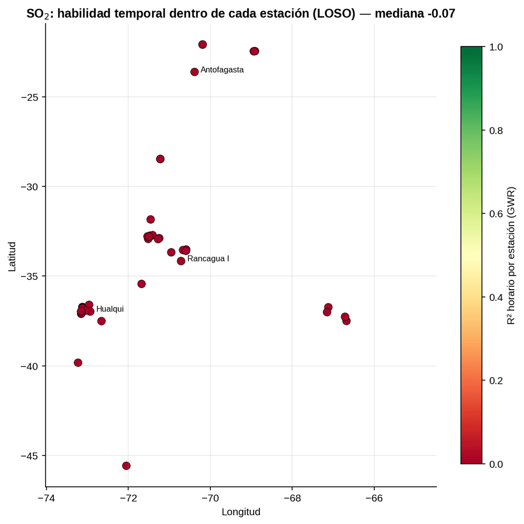

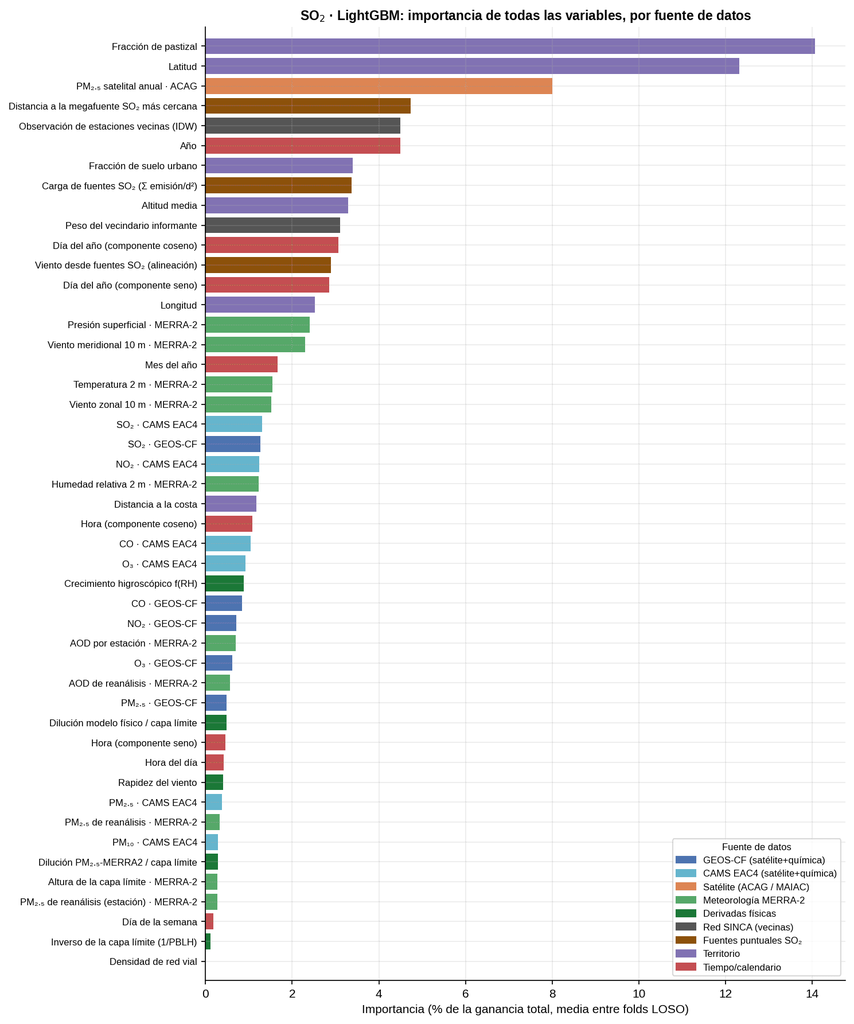

**CO**

**Lectura.** El mejor motor LOSO para CO horario es **LightGBM** (R² horario **0.22**, RMSE 0.7; agregado a medias diarias R² **0.22**; el modelo físico crudo queda en -0.19 horario).

#### 4.1.21 Nacional (R² agrupado LOSO)

| motor | R² horario | RMSE h | MAE h | sesgo h | R² diario | RMSE d |
| --- | --- | --- | --- | --- | --- | --- |
| Modelo físico crudo | -0.191 | 0.856 | 0.427 | -0.323 | -0.344 | 0.672 |
| GWR | 0.185 | 0.708 | 0.345 | -0.013 | 0.215 | 0.514 |
| Regression-kriging | 0.17 | 0.714 | 0.369 | 0.061 | 0.202 | 0.518 |
| LightGBM | 0.223 | 0.691 | 0.332 | 0.001 | 0.224 | 0.511 |

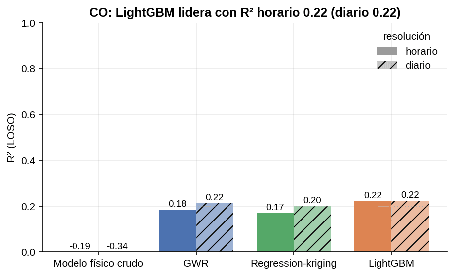

#### 4.1.22 Por macrozona

R² **agrupado** LOSO por macrozona del mejor motor (todas las horas de la macrozona juntas):

| macrozona | n horas | R² | RMSE | MAE | sesgo |
| --- | --- | --- | --- | --- | --- |
| Norte Grande | 94250.0 | -0.036 | 0.565 | 0.265 | 0.152 |
| Norte Chico | 48208.0 | -0.084 | 0.933 | 0.423 | -0.249 |
| Centro | 777351.0 | 0.484 | 0.437 | 0.249 | 0.004 |
| Sur | 627275.0 | 0.118 | 0.895 | 0.426 | 0.006 |
| Austral | 51530.0 | 0.206 | 0.887 | 0.461 | -0.133 |

R² LOSO **mediano por estación**, por motor (la vara dura: habilidad temporal en la estación no vista):

| zona | estaciones | R² med. físico crudo | R² med. GWR | R² med. RK | R² med. LGBM | mejor motor | RMSE mediano (mejor) |
| --- | --- | --- | --- | --- | --- | --- | --- |
| Norte Grande | 3 | -1.339 | -0.306 | -0.272 | -0.03 | LGBM | 0.59 |
| Norte Chico | 1 | -0.397 | -0.116 | -0.039 | -0.084 | RK | 0.91 |
| Centro | 17 | -0.151 | 0.271 | 0.301 | 0.321 | LGBM | 0.4 |
| Sur | 16 | -0.34 | 0.065 | 0.055 | 0.057 | GWR | 0.76 |
| Austral | 1 | -0.415 | 0.165 | 0.151 | 0.206 | LGBM | 0.89 |

#### 4.1.23 Por región

| zona | estaciones | R² med. físico crudo | R² med. GWR | R² med. RK | R² med. LGBM | mejor motor | RMSE mediano (mejor) |
| --- | --- | --- | --- | --- | --- | --- | --- |
| Antofagasta | 3 | -1.339 | -0.306 | -0.272 | -0.03 | LGBM | 0.59 |
| Atacama | 1 | -0.397 | -0.116 | -0.039 | -0.084 | RK | 0.91 |
| Valparaíso | 6 | -0.414 | -0.486 | -0.829 | -0.438 | LGBM | 0.31 |
| Metropolitana | 9 | 0.066 | 0.523 | 0.443 | 0.617 | LGBM | 0.41 |
| O’Higgins | 1 | -0.404 | 0.271 | 0.343 | 0.321 | RK | 0.37 |
| Maule | 1 | -0.398 | 0.221 | 0.227 | 0.234 | LGBM | 0.82 |
| Biobío–Ñuble | 13 | -0.346 | 0.048 | 0.035 | -0.031 | GWR | 0.79 |
| Araucanía | 2 | -0.101 | 0.237 | 0.247 | 0.259 | LGBM | 0.86 |
| Los Ríos | 1 | -0.522 | 0.163 | 0.216 | 0.218 | LGBM | 0.62 |
| Aysén | 1 | -0.415 | 0.165 | 0.151 | 0.206 | LGBM | 0.89 |

#### 4.1.24 Mapa e importancias

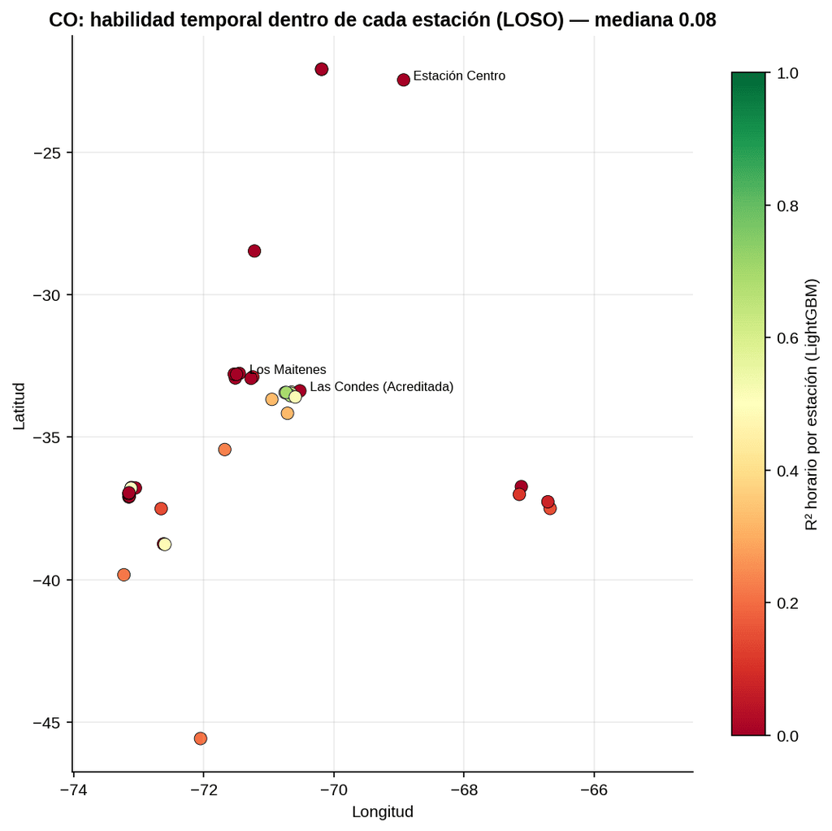

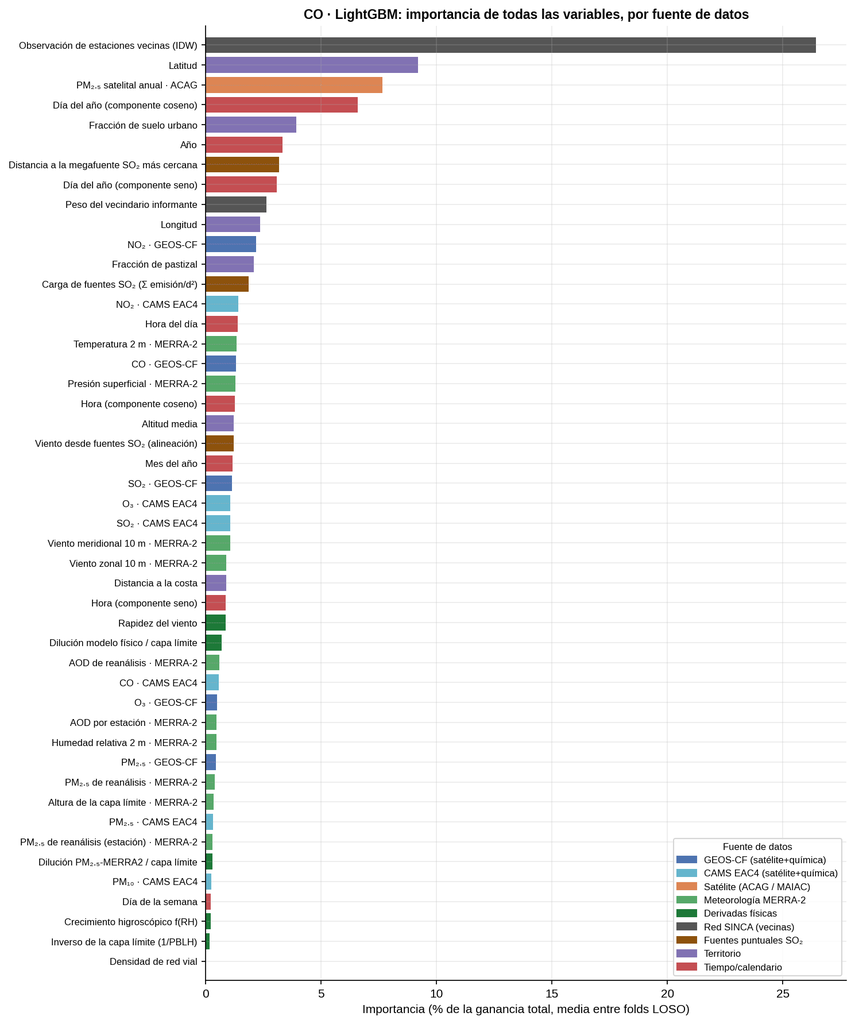

## 5 Series de tiempo: modelos calibrados vs. SINCA

**PM₂.₅**

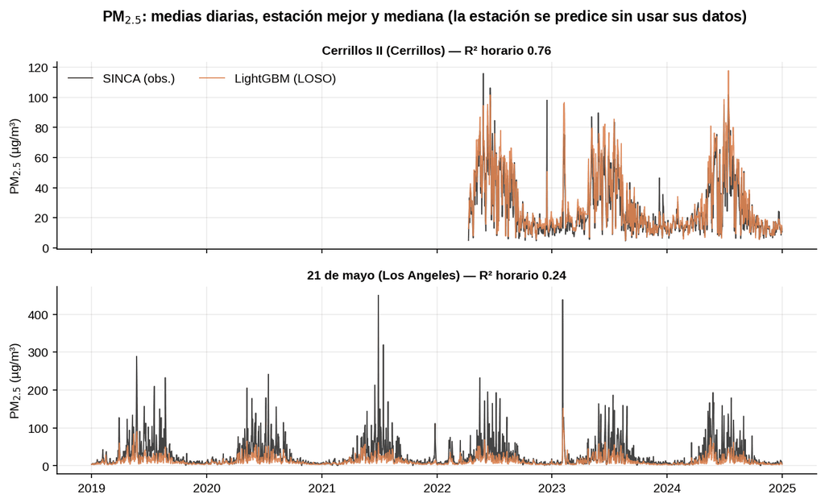

**PM₁₀**

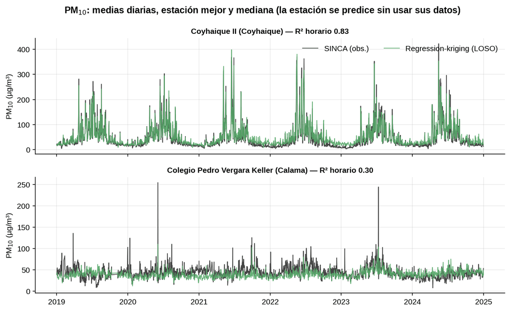

**NO₂**

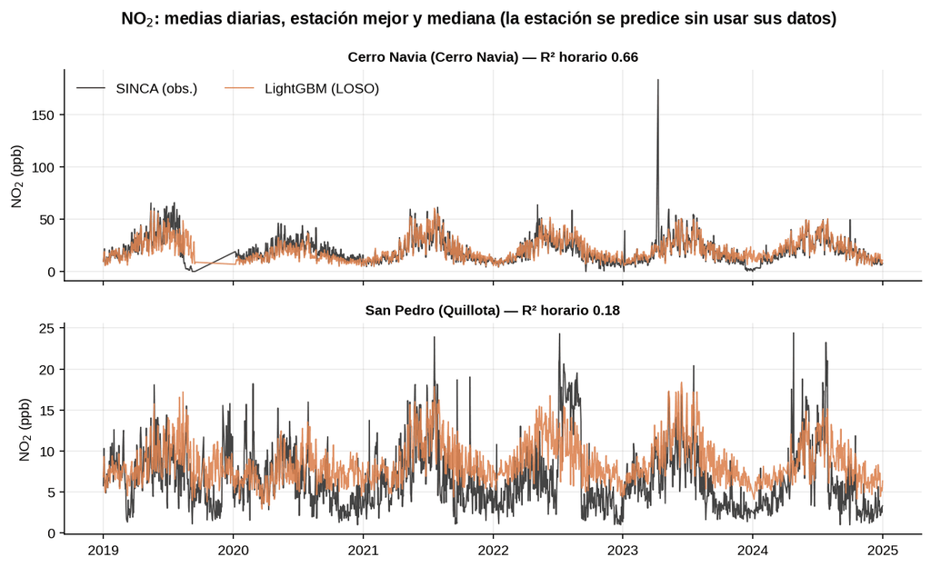

**O₃**

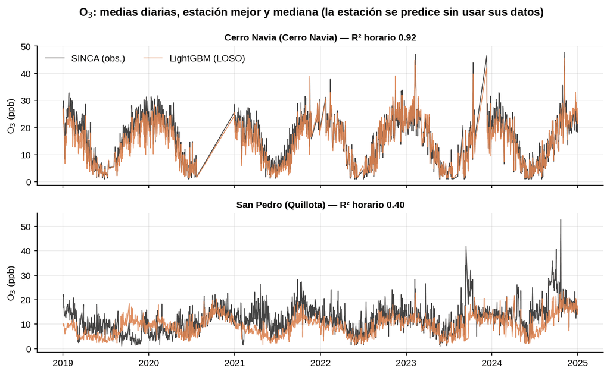

**SO₂**

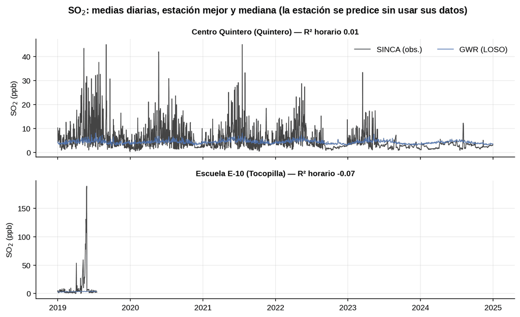

**CO**

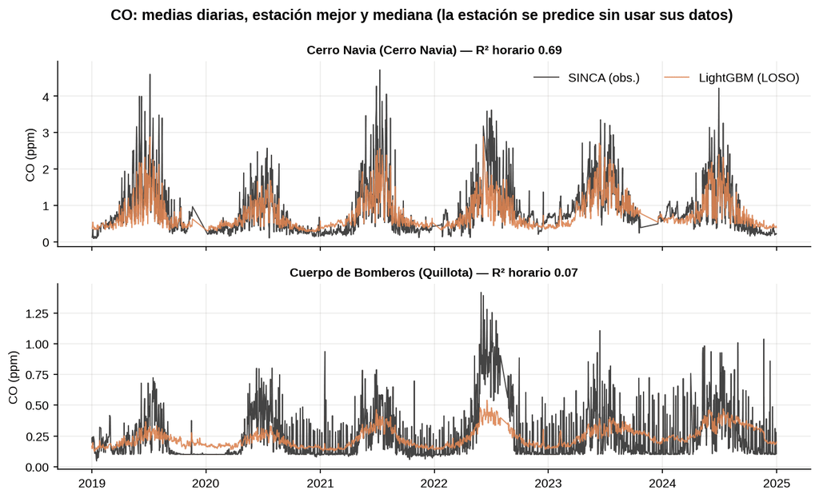

## 6 Correlaciones modelo ↔︎ SINCA

El cierre cuantitativo: la dispersión observación–predicción de los modelos calibrados, bajo los dos protocolos de Sección 2.7. Primero el resumen comparado; luego, por contaminante, la dispersión LOSO por motor (horaria y diaria) y la dispersión diaria del **producto final** (entrenado con todas las estaciones).

**Protocolo del producto para los seis contaminantes**

```python
prot = {pol: protocolo_producto(pol) for pol in CONTAMINANTES}
filas = []
for pol in CONTAMINANTES:
    m = mejor_motor(resultados[pol])
    filas.append({
        "contaminante": NOMBRE_POL_TXT[pol],
        "producto diario r² (Pearson)": prot[pol]["r2_pearson"],
        "producto diario R² clásico": prot[pol]["r2_clasico"],
        "LOSO diario R² (mejor motor)": resultados[pol]["motores"][m]["diario"]["r2"],
        "LOSO horario R²": resultados[pol]["motores"][m]["horario"]["r2"]})
pd.DataFrame(filas).set_index("contaminante")
```

Tabla 10: Producto final (acuerdo diario in-situ) vs. LOSO (fuera-de-estación), por contaminante.

| contaminante | producto diario r² (Pearson) | producto diario R² clásico | LOSO diario R² (mejor motor) | LOSO horario R² |
| --- | --- | --- | --- | --- |
| PM₂.₅ | 0.7433 | 0.7344 | 0.4994 | 0.3680 |
| PM₁₀ | 0.7749 | 0.7731 | 0.5117 | 0.3727 |
| NO₂ | 0.7861 | 0.7858 | 0.5504 | 0.4845 |
| O₃ | 0.8648 | 0.8647 | 0.3176 | 0.5437 |
| SO₂ | 0.5283 | 0.4801 | 0.0567 | 0.0159 |
| CO | 0.8090 | 0.7905 | 0.2245 | 0.2231 |

**Lectura.** Bajo el protocolo del producto, el pipeline alcanza para PM₂.₅ un r² diario de **0.74**, y bajo LOSO estricto **0.50** diario. La diferencia entre ambos números no es un defecto: es la medida de cuánto cuesta extrapolar a comunas sin monitor — la misma brecha que la literatura reporta al pasar de CV convencional a estaciones no vistas (0,80–0,84 → 0,61–0,70).

**PM₂.₅**

#### 6.0.1 Dispersión LOSO (horaria y diaria, por motor)

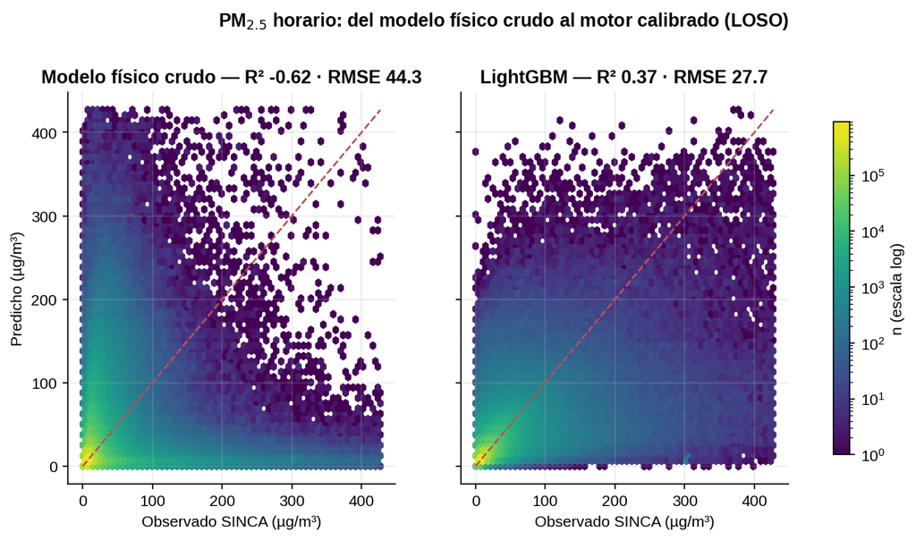

#### 6.0.2 Dispersión diaria del producto final

**Protocolo del producto** — acuerdo diario del modelo final entrenado con todas las estaciones: N = 185,084 días·estación, r² de Pearson **0.74**, R² clásico 0.73, RMSE 12.2; recta OLS y = 5.51 + 0.67·x.

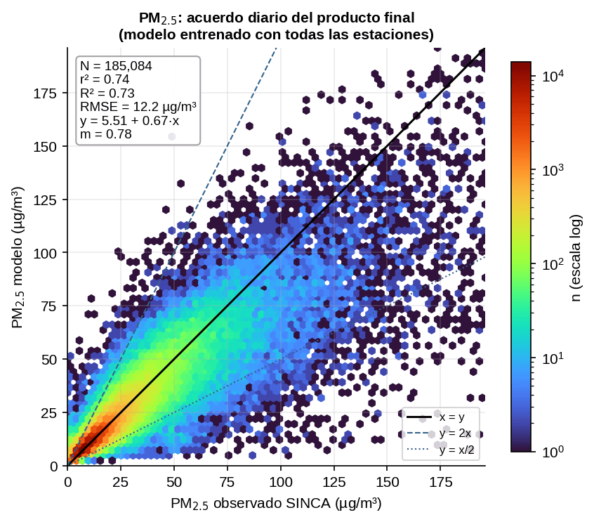

**PM₁₀**

#### 6.0.3 Dispersión LOSO (horaria y diaria, por motor)

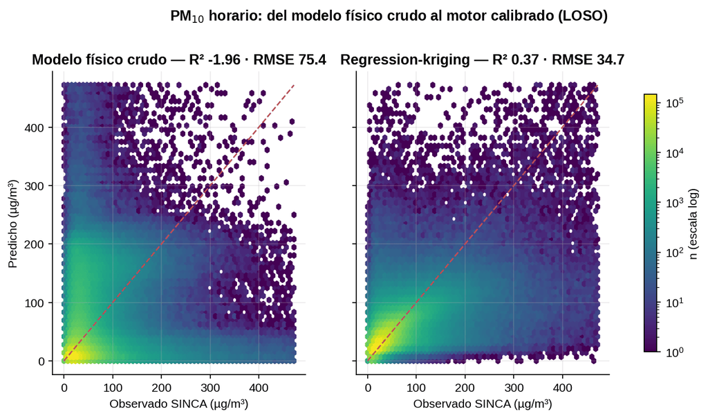

#### 6.0.4 Dispersión diaria del producto final

**Protocolo del producto** — acuerdo diario del modelo final entrenado con todas las estaciones: N = 149,126 días·estación, r² de Pearson **0.77**, R² clásico 0.77, RMSE 14.0; recta OLS y = 9.95 + 0.74·x.

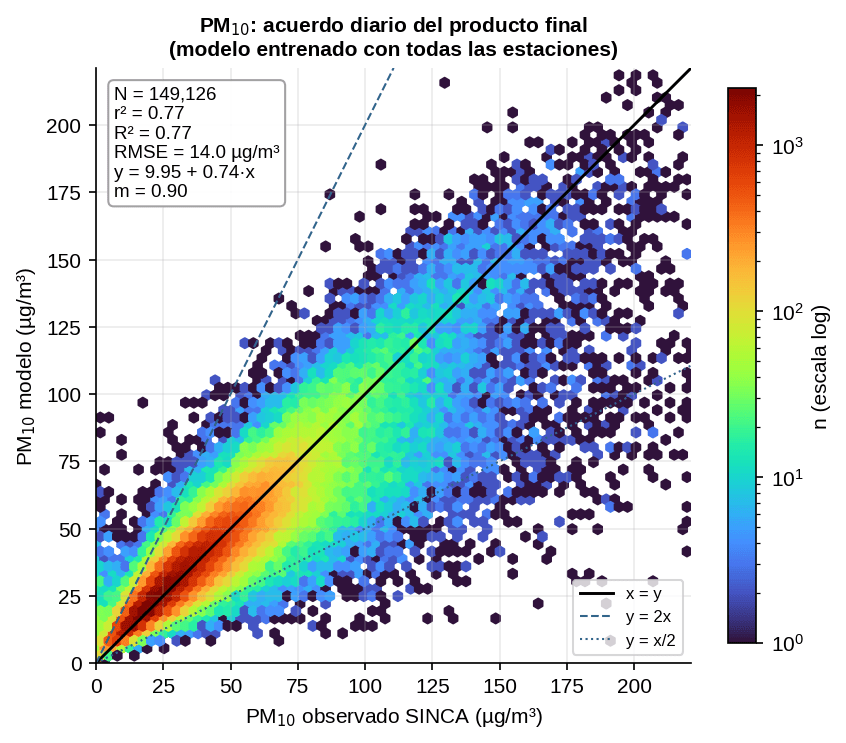

**NO₂**

#### 6.0.5 Dispersión LOSO (horaria y diaria, por motor)

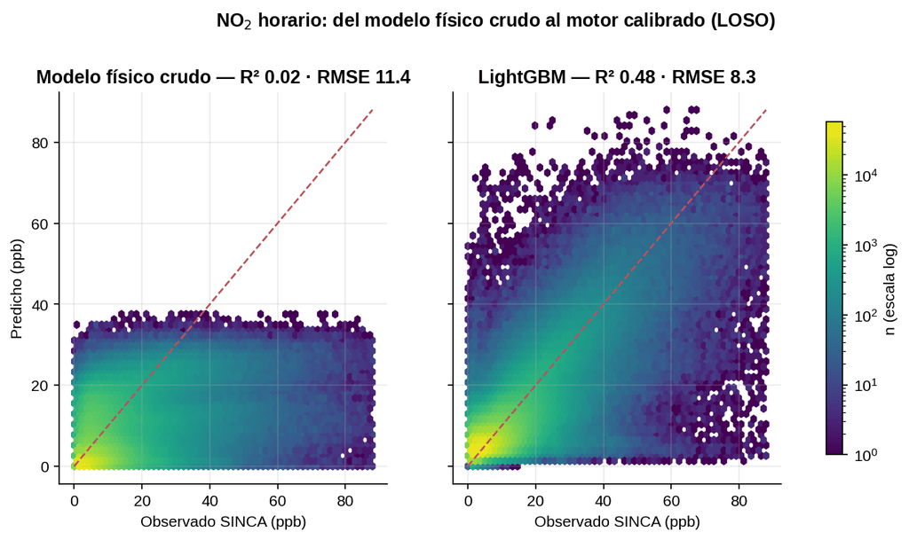

#### 6.0.6 Dispersión diaria del producto final

**Protocolo del producto** — acuerdo diario del modelo final entrenado con todas las estaciones: N = 80,478 días·estación, r² de Pearson **0.79**, R² clásico 0.79, RMSE 4.5; recta OLS y = 2.09 + 0.78·x.

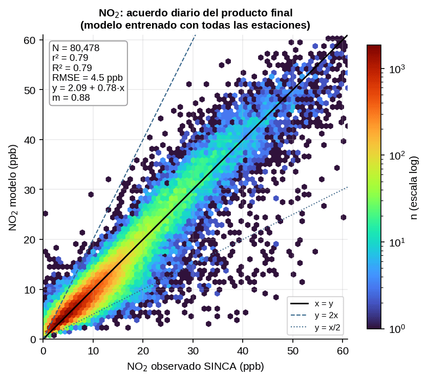

**O₃**

#### 6.0.7 Dispersión LOSO (horaria y diaria, por motor)

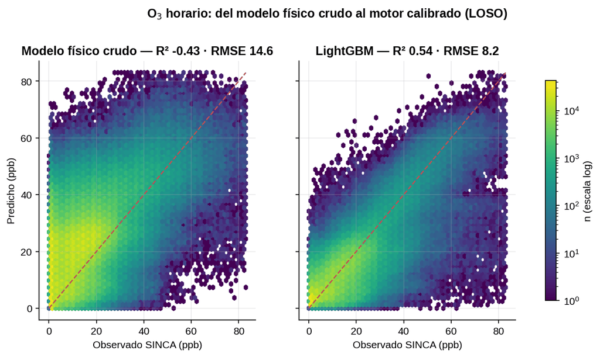

#### 6.0.8 Dispersión diaria del producto final

**Protocolo del producto** — acuerdo diario del modelo final entrenado con todas las estaciones: N = 77,682 días·estación, r² de Pearson **0.86**, R² clásico 0.86, RMSE 2.9; recta OLS y = 2.05 + 0.85·x.

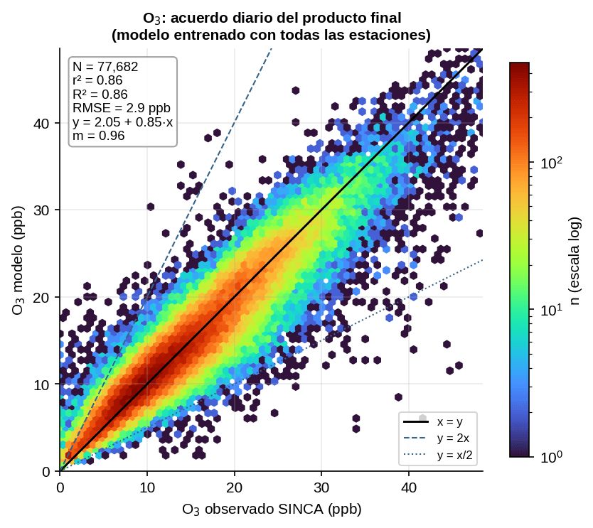

**SO₂**

#### 6.0.9 Dispersión LOSO (horaria y diaria, por motor)

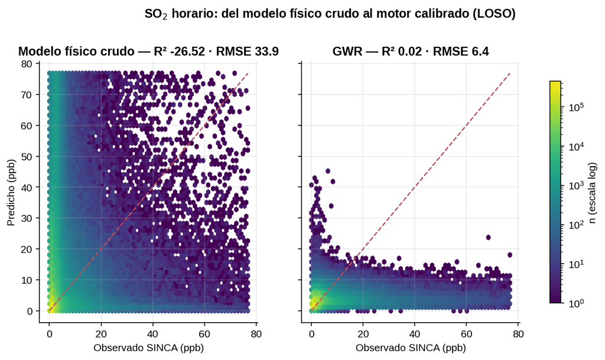

#### 6.0.10 Dispersión diaria del producto final

**Protocolo del producto** — acuerdo diario del modelo final entrenado con todas las estaciones: N = 82,248 días·estación, r² de Pearson **0.53**, R² clásico 0.48, RMSE 2.9; recta OLS y = 1.29 + 0.38·x.

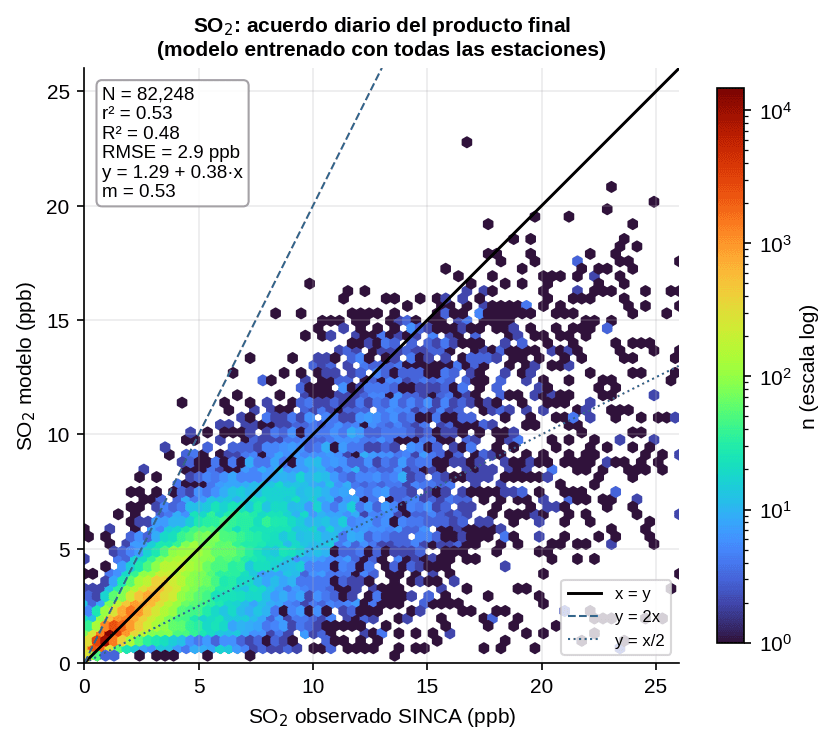

**CO**

#### 6.0.11 Dispersión LOSO (horaria y diaria, por motor)

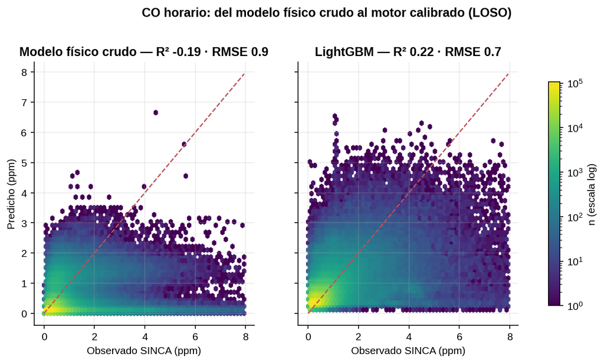

#### 6.0.12 Dispersión diaria del producto final

**Protocolo del producto** — acuerdo diario del modelo final entrenado con todas las estaciones: N = 68,560 días·estación, r² de Pearson **0.81**, R² clásico 0.79, RMSE 0.3; recta OLS y = 0.16 + 0.69·x.

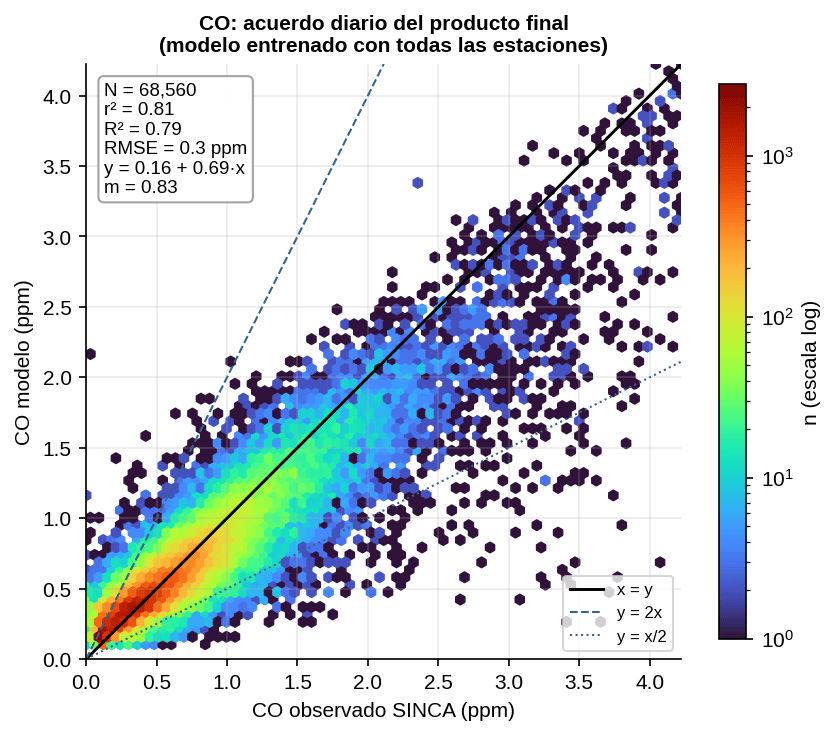

## 7 Síntesis

- **PM₂.₅** — mejor motor LightGBM: R² horario 0.37, diario 0.50 (físico crudo: -0.62); producto diario r² 0.74.

- **PM₁₀** — mejor motor Regression-kriging: R² horario 0.37, diario 0.51 (físico crudo: -1.96); producto diario r² 0.77.

- **NO₂** — mejor motor LightGBM: R² horario 0.48, diario 0.55 (físico crudo: 0.02); producto diario r² 0.79.

- **O₃** — mejor motor LightGBM: R² horario 0.54, diario 0.32 (físico crudo: -0.43); producto diario r² 0.86.

- **SO₂** — mejor motor GWR: R² horario 0.02, diario 0.06 (físico crudo: -26.52); producto diario r² 0.53.

- **CO** — mejor motor LightGBM: R² horario 0.22, diario 0.22 (físico crudo: -0.19); producto diario r² 0.81.

Cuatro lecturas transversales:

1. **La calibración estadística es la que crea el producto.** El modelo físico crudo (GEOS-CF/CAMS en el píxel de la estación) explica poco de la varianza horaria observada — consistente con la brecha de resolución (0,25–0,75° vs. comunas heterogéneas) y con que Sudamérica no cuenta con un producto ajustado propio. Todo el salto de desempeño viene de los motores corregidos contra SINCA, igual que en la literatura ancla.
2. **El boosting domina en horario; la GWR y el kriging se defienden en la señal persistente.** LightGBM captura no-linealidades e interacciones (química cruzada, ciclos), mientras GWR/RK levantan sobre todo el nivel medio local. Ojo con la relación horario/diario: en contaminantes dominados por el ciclo diurno fotoquímico (O₃) el R² horario puede *superar* al diario — el ciclo es muy predecible —, mientras que en los particulados con episodios (leña, polvo) agregar a día siempre ayuda.
3. **R² agrupado ≠ R² por estación.** El agrupado premia acertar los *niveles* entre estaciones; el mediano por estación mide la habilidad *temporal* dentro de cada estación no vista, y es sistemáticamente menor (Sección 4, tablas por macrozona y región). Ambos son correctos y responden preguntas distintas — para exposición epidemiológica el contraste espacial suele importar más; para alertas de episodios manda el temporal.
4. **Las macrozonas y regiones con redes ralas son el caso difícil esperado**: las tablas por nivel documentan exactamente dónde duele (norte minero para SO₂, austral para casi todo), insumo directo para la discusión de brechas del proyecto.

## 8 Limitaciones y próximos pasos

- **Predictores en cola**: los datos crudos de TROPOMI (NO₂), OMI (NO₂, SO₂, O₃), MOPITT (CO) y MAIAC 1 km ya están descargados y los extractores por estación están escritos y probados (`scripts_superficie/extractores/`, con README y tiempos); sus tablas estación × día entran como columnas nuevas de `tabla_predictores()` sin tocar los motores. ERA5-Land (meteorología 0,1° y **precipitación**, hoy ausente) tiene su script de descarga CDS en la misma carpeta; faltan por descargar TROPOMI SO₂/CO/O₃, luces nocturnas y censo/leña.
- **Fuentes puntuales de SO₂**: la tabla de megafuentes usa pesos de emisión de orden de magnitud y coordenadas aproximadas (± 2 km); el paso siguiente es reemplazarlos por las emisiones anuales declaradas en el RETC por establecimiento y año (varias fuentes cambiaron de régimen en el periodo: cierre de Ventanas en 2023, retiro de unidades a carbón en Tocopilla y Bocamina).
- **De estaciones a comunas**: este documento valida el *modelo*; el paso siguiente es aplicar el mejor motor a la grilla y agregar a comunas (superficie de exposición).
- **Supuestos de tiempo**: SINCA se asume en hora local continental (`America/Santiago`) con etiqueta al inicio de la hora; GEOS-CF a media hora se lleva al inicio de hora; la meteorología comunal declara `fecha_local`+`hora` y se convierte a UTC con la zona oficial (verificado con el pico diurno de PBLH).
- **Insumos comunales**: la meteorología, el MAIAC y las estáticas se leen pre-procesados a nivel de comuna; cada estación hereda el valor de su comuna (aceptable a 0,5°; la versión por estación llega con las descargas nativas).
- **Datos**: cuatro estaciones con coordenadas corruptas en `estaciones.csv` quedan fuera hasta corregir el maestro — *Concón MMA* (inf), *Quintero* (lat 56,6/lon 114,9), *La Palma* (lon −44) y *Entre Lagos* (lon −78,6); los meses de GEOS-CF del OPeNDAP mezclan unidades por archivo (se normalizan por magnitud, Sección 2.2.2).
- **Motores**: la GWR horaria usa coeficientes por estación objetivo (no por celda); el RK kriegea el residuo medio (clima) y no el residuo hora a hora. Ambas son las adaptaciones mínimas honestas para LOSO horario masivo; la versión por celda llega con la superficie comunal.
- **Convención RFSI** de `obs_vec` bajo LOSO descrita en Sección 2.7; la variante estricta (vecindarios recalculados por fold) está anotada como mejora posible.

## 9 Reproducibilidad

```
# render normal (usa la caché de output_files/: si los artefactos chicos
# están, el documento se reconstruye completo sin recomputar nada pesado)
quarto render docs/modelos_estimacion.qmd

# regenerar un artefacto puntual: bórralo y re-renderiza
rm output_files/metricas_cv_no2.json output_files/oof_no2.parquet
quarto render docs/modelos_estimacion.qmd

# regenerar una figura: borra el PNG en output_files/figures/
# regenerar las series por nivel: borra serie_mensual_<pol>.csv

# corrida de prueba rápida (submuestra, caché aparte en output_files/_smoke/)
AFG_SMOKE=1 quarto render docs/modelos_estimacion.qmd

# perillas: AFG_MAX_TRAIN_ROWS (300000), AFG_N_TREES (600),
#           AFG_LOG_TARGET (1), AFG_REPO_ROOT, AFG_NEURO_ROOT
```

Los extractores por estación de los productos satelitales pendientes (TROPOMI, OMI, MOPITT, MAIAC) y el script de descarga de ERA5-Land viven en `scripts_superficie/extractores/` (README con entorno, orden y tiempos); se corren donde están los datos crudos y dejan tablas chicas en `data/procesado_estacion/`.

Entorno: Python ≥ 3.11 con `numpy pandas pyarrow xarray netCDF4 scipy scikit-learn lightgbm matplotlib`. Artefactos versionables por contaminante: `metricas_cv_*.json`, `metricas_producto_*.json`, `comparacion_motores_*.csv`, `importancias_*.csv`, `r2_estacion_*.csv`, `acuerdo_niveles_*.csv`, `serie_mensual_*.csv`, `resumen_predictores.csv` y `figures/*.png` — con ellos presentes, el HTML se re-renderiza íntegro sin los datos crudos ni los paneles. Tiempos de referencia de la corrida completa (2 CPU): tabla de predictores ~2 min; panel por contaminante ~1 min; GWR ~10 s y RK ~3 min por contaminante; LightGBM LOSO es el costo dominante (~10–40 min por contaminante según estaciones).